# Technical Report: Full House Model in R

Version 2

# Introduction

We will go through examples of how our Full House Model era-adjusts batting averages (BA) using the parametric method, and bWAR (Baseball-Reference Win Above Replacement), fWAR (Fangraphs Win Above Replacement), HR (Home Run), BB (Walks) for batters, bWAR, fWAR, ERA (Earned Run Average), SO (Strikeout) for pitchers using the nonparametric method. Also we provide details about how the tables and figures in the paper and supplementary materials are produced.

We first load in relevant software packages and the data. The necessary data are collected from [Baseball-Reference](https://www.baseball-reference.com/), [Fangraphs](https://www.fangraphs.com/) and Github [Chadwick](https://github.com/chadwickbureau). The details of data collection are in the Supplement Materials. The revelant datasets that involved in this technical report can be found in the Tech_report_data

For batters, each row of data consists of a player ID, a year ID, a name, a age, a league ID (lgID), a recorded number of at bats (AB), game(G), plate appearances (PA), a park-factored batting average (BA), a walk (BB), a observed hits (obs_hits), observed home run (obs_HR), a hit-by-pitch (HBP), a sacrifice bunt (SH), a sacrifice fly (SF), a park-factored hits (H), a park-factored home run (HR), a baseball-reference WAR (bWAR), a fangraph WAR (fWAR) and a size of the MLB-eligible population (pops).

For pitchers, each row of data consists of a player ID, a year ID, a name, a age, a league ID (lgID), a team ID (teamID), a recorded number of inning pitched (IP) and a game(G), a observed earned run (obs_ER), a observed home run (obs_HR), a observed hits (obs_H), a strikeout (SO), a park-factored earned run (ER), a park-factored home run (HR_PF), a park-factored hits (H_PF), a walk (BB), a hit-by-pitch (HBP), a baseball-reference WAR (bWAR), a fangraph WAR (fWAR) and a size of the MLB-eligible population (pops).

```r
rm(list=ls())
library(tidyverse)
library(orderstats)
library(Pareto)
library(doParallel)
library(splines)
library(retrosheet)
library(kableExtra)
library(Lahman)
ncores <- detectCores() - 1
years <- 1871:2023

load("bat_dat.RData")
load("pit_dat.RData")
source('source.R')
```

In this analysis we assume that BA $\stackrel{i i d}{\sim} N\left(\mu_{i}, \sigma_{i}\right)$ and that talent scores $\stackrel{i i d}{\sim} \operatorname{Pareto}(\alpha)$ where $\alpha=1.16$. We do not have any assumptions on the distribution of the baseball statistics. This choice of alpha corresponds to the Pareto principle which is casually referred to as the $80 / 20$ rule.

# Batters

In this section, our Full House Model era-adjusts batting statistics, such as bWAR, fWAR, HR, BB and BA using the nonparametric distribution measuring the components. We also apply our Full House Model to era-adjuste BA using the parametric distribution measuring the components.

## bWAR

We now try out the bWAR for batters and first we select the full-time batters. We declare the median PA after screening out individuals who batted fewer than 75 PA as our cutoff for full-time batters.

```r
batters <- bat_dat %>% select(yearID, playerID, lgID, name, age, PA, G, bWAR, pops)
cutoff <- do.call(rbind, mclapply(years, mc.cores = ncores, FUN = function(xx){
    m <- batters %>% filter(yearID == xx) %>% filter(PA >= 75)
    data.frame(thres = median(m$PA), yearID = xx)
  }))
batters <- merge(batters, cutoff, by = 'yearID')
batters <- batters %>% mutate(comp =  bWAR / G, full_time = ifelse(PA >= thres, 'Y', 'N'))
```

In the [1994 and 1995](https://en.wikipedia.org/wiki/1994%E2%80%9395_Major_League_Baseball_strike), hitters and pitchers played fewer games per season than the regular season. To deal with extreme statistics from the small sample size, we motivated a shrinkage method that adjust the raw statistics toward a global average. Our shrinkage method follows a shrinkage of ballpark effect estimates motivated from Michael Schell’s book, [Baseball’s All-Time Best Sluggers](https://www-jstor-org.proxy2.library.illinois.edu/stable/j.ctt19705ks.25?seq=8). This methods involves weighted average of raw components and league average, which is

$$\textrm{adjusted component} =
(\textrm{raw components} \times \textrm{total ABs} + 4000 \times
\textrm{league average})/(\textrm{totals AB + 4000})$$
When we use the shrinkage method to analyze our seasonal data, the shrinkage factor $4000 / (\textrm{totals AB + 4000})$ get adjusted based on fraction of 4000 to the totals AB of the MLB teams. For example,
$$\textrm{adjusted bWAR per game} = (\textrm{raw
bWAR per game} \times \textrm{game} + 7 \times \textrm{league
average})/(\textrm{game + 7})$$

```r
batters_schell <- do.call(rbind, mclapply(years, mc.cores = ncores, FUN = function(xx){
    int<- batters %>% filter(yearID == xx)
    lg_avg <- sum(int$bWAR)/sum(int$G)
    int %>% mutate(comp = (bWAR + lg_avg * 7)/(G + 7))
  }))
```

```r
batters_talent_bWAR <- do.call(rbind, mclapply(years, mc.cores = ncores, function(yy){
  talent_computing_nonpara(dataset = batters_schell, component_name = "bWAR", year = yy, ystar = thresh_fun(component = batters_schell %>% filter(full_time == 'Y', yearID == yy) %>% select(comp), component_name = 'bWAR'), alpha = 1.16) })) %>% arrange(-WAR_talent)
```

We built a common mapping environment with regard to the provided season size based on the no-strike seasons rather than utilizing one specific season from 1871 to 2022 as the projected season. To acquire era-adjusted statistics, we project the players’ talent to this common mapping environment. [Micheal Schell](https://www-jstor-org.proxy2.library.illinois.edu/stable/j.ctt19705ks.6?seq=15) inspired us to use the National League seasons from 1977 through 1989, with the exception of the 1981 strike season, as the common mapping environment. The number of teams in these seasons that we choose remains constant in order to prevent the Major League’s expansion effect. We then construct an isotonic regression model of the corresponding components on the ordered talent scores. In the common mapping environment, this model provides the association between the components and the talent scores.

We set the total number of full-time players throughout all seasons to be equal to the number of components in the common mapping environment. This is due to the fact that the more components in the common mapping environment, the $\widetilde{F}_{Y_i}(t)$ and $F_{Y_i}(t)$ are more closely. Then we select this number of components based on the quantile mapping and the quantiles of the components are equally spaced. The talent scores of the components we choose from the common mapping environment are calculated using the isotonic regression model. Now we construct the common mapping environment completely.

```r
no_strike <- batters_talent_bWAR %>%
    filter(yearID < 1990, yearID >= 1977, yearID != 1981,
           full_time == 'Y', lgID == 'NL') %>%
    arrange(WAR_talent)

t <- isoreg(no_strike$WAR_talent, no_strike$comp)
talent_new <- quantile(no_strike$WAR_talent, probs = (seq(0,250)/250))
comp_new <- as.stepfun(t)(talent_new)
```

The figure below shows the relationship between bWAR talent and bWAR per game. The black dots represent the observations from the full-time batters from the 1977 season to 1989 season with the exception of the 1981 strike season. The red dots represent the observations from the common mapping environment that we define above. Based on the figure above, the observations from the common mapping environment accurately depict the relationship between bWAR talent and bWAR per game from the 1977 season to the 1989 season with the exception of the 1981 strike season.

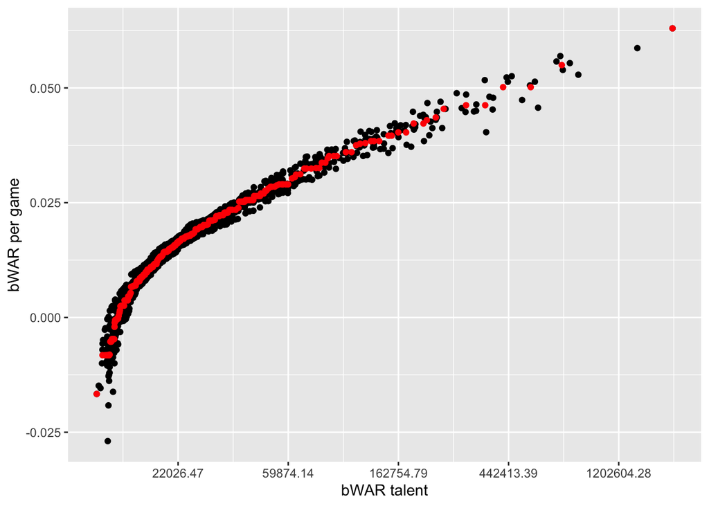

```r
mapping_envir <- data.frame(talent_new = talent_new, comp_new = comp_new)
ggplot(data = no_strike, aes(x = WAR_talent, y = comp)) + geom_point() +
  geom_point(data = mapping_envir, aes(x = talent_new, y = comp_new), color = 'red') +
  labs(x = 'bWAR talent', y = 'bWAR per game') +
  scale_x_continuous(trans='log')
```

```r
ystar <- thresh_fun(comp_new, component_name = 'bWAR')
pop_new <- round(mean(no_strike$pops))
component_name = 'bWAR'
yy <- sort(comp_new)
n <- length(yy)
ytilde <- rep(0, n + 1)
if (component_name == 'bWAR' | component_name == 'fWAR') {
    ytilde[1] <- yy[1] - (yy[2] - yy[1])
}
if (component_name == 'HR' | component_name == 'BB') {
    # since the minimal HR is greater or equal to 0.
    ytilde[1] <- 0
}
ytilde[n+1] <- yy[n] + ystar
ytilde[2:n] <- unlist(lapply(2:n, function(j){
    (yy[j]+yy[j-1])/2
}))
```

We now extend the method to compute hypothetical careers in the common mapping environment and obtain the era-adjusted statistics.

```r
career_kAB_1st <- do.call(rbind, mclapply(1:30000, function(zz){
    int <- career_talent_nonpara(dataset = batters_talent_bWAR, component_name = 'bWAR',
                         snippet = batters_talent_bWAR[zz,], alpha = 1.16)
    int
  }, mc.cores = ncores))


career_kAB_2nd <- do.call(rbind, mclapply(30001:60000, function(zz){
    int <- career_talent_nonpara(dataset = batters_talent_bWAR, component_name = 'bWAR',
                         snippet = batters_talent_bWAR[zz,], alpha = 1.16)
    int
  }, mc.cores = ncores))

career_kAB_3rd <- do.call(rbind, mclapply(60001:nrow(batters_talent_bWAR), function(zz){
    int <- career_talent_nonpara(dataset = batters_talent_bWAR, component_name = 'bWAR',
                         snippet = batters_talent_bWAR[zz,], alpha = 1.16)
    int
  }, mc.cores = ncores))

career_kAB <- rbind(career_kAB_1st, career_kAB_2nd, career_kAB_3rd)
```

Instead of using the raw G and PA in the data set, we calculate the mapped G by applying quantile mapping for the full-time hitters and non-full-time hitters separately. Quantile mapping is based on that a pth percentile player’s games in one year is equal to a pth percentile player’s games in the common mapping environment.

We also specify that worst performance of bWAR for the full time players in each season -2.

```r
## mapping statistics

mapped_quan_b_raw <- do.call(rbind, mclapply(years, function(xx){
    batters_full <- batters %>% filter(yearID == xx) %>%
      filter(full_time == 'Y') %>% arrange(-G)
    batters_less <- batters %>% filter(yearID == xx) %>%
      filter(full_time == 'N') %>% arrange(-G)

    n1 <- nrow(batters_full)
    n2 <- nrow(batters_less)

    mapped_G_full <- c()
    mapped_G_less <- c()
    for (yy in c(1977:1980, 1982:1989)) {
      batters_ref_full <- batters %>%
        filter(yearID == yy, full_time == 'Y') %>% arrange(-G)
      batters_ref_less <- batters %>%
        filter(yearID == yy, full_time == 'N') %>% arrange(-G)
      n1r <- nrow(batters_ref_full)
      n2r <- nrow(batters_ref_less)

      mapped_G_full <- cbind(mapped_G_full, approx(x = seq((n1r-1),0)/(n1r-1),
                                                   y = batters_ref_full$G,
                                                   xout = seq((n1-1),0)/(n1-1))$y)
      mapped_G_less <- cbind(mapped_G_less, approx(x = seq((n2r-1),0)/(n2r-1),
                                                   y = batters_ref_less$G,
                                                   xout = seq((n2-1),0)/(n2-1))$y)
    }

    batters_full$mapped_G <- rowMeans(mapped_G_full)
    batters_less$mapped_G <- rowMeans(mapped_G_less)


    batters_full <- batters_full %>% arrange(-PA)
    batters_less <- batters_less %>% arrange(-PA)
    mapped_PA_full <- c()
    mapped_PA_less <- c()
    for (yy in c(1977:1980, 1982:1989)) {
      batters_ref_full <- batters %>%
        filter(yearID == yy, full_time == 'Y') %>% arrange(-PA)
      batters_ref_less <- batters %>%
        filter(yearID == yy, full_time == 'N') %>% arrange(-PA)
      n1r <- nrow(batters_ref_full)
      n2r <- nrow(batters_ref_less)

      mapped_PA_full <- cbind(mapped_PA_full, approx(x = seq((n1r-1),0)/(n1r-1),
                                                     y = batters_ref_full$PA,
                                                     xout = seq((n1-1),0)/(n1-1))$y)
      mapped_PA_less <- cbind(mapped_PA_less, approx(x = seq((n2r-1),0)/(n2r-1),
                                                     y = batters_ref_less$PA,
                                                     xout = seq((n2-1),0)/(n2-1))$y)
    }

    batters_full$mapped_PA <- rowMeans(mapped_PA_full)
    batters_less$mapped_PA <- rowMeans(mapped_PA_less)

    m <- rbind(batters_full, batters_less)
    data.frame(playerID = m$playerID, yearID = m$yearID,
               mapped_G_raw = round(m$mapped_G), mapped_PA_raw = round(m$mapped_PA))

  }, mc.cores = ncores))

mapped_batters_1 <- merge(career_kAB, mapped_quan_b_raw,
                            by = c('playerID', 'yearID'))

min_refbWAR <- -2

mapped_batters_bWAR <- mapped_batters_1 %>%
    mutate(adj_bWAR = adj_comp * mapped_G_raw) %>%
    mutate(adj_bWAR = ifelse(adj_bWAR < min_refbWAR, min_refbWAR, adj_bWAR)) %>%
    mutate(mapped_G_bWAR = round(adj_bWAR / adj_comp))
```

Then we apply the same techniques for fWAR.

We also apply our full house model to BB and HR. Before we do that, we get lower bounds on walk rate and home run rate. We isolate players with batting records from the common mapping environment and restrict attention to players with 10 years of batting records. Then we obtain the 0.03rd quantile of walk rate and home run rate for the these players for seasons in which they obtained at least 400 PAs and serve the quantiles as minimum allowable rates in the common mapping environment.

```r
IDs7789 = Batting %>%
  filter(yearID >= 1977, yearID <= 1989, yearID != 1981) %>%
  pull(playerID)

IDs10 = Batting %>%
  filter(playerID %in% IDs7789) %>%
  group_by(playerID) %>%
  summarise(n = n()) %>%
  filter(n >= 10) %>%
  pull(playerID)

lowerb <- Batting %>%
  filter(playerID %in% IDs10) %>%
  filter(yearID >= 1977, yearID <= 1989, yearID != 1981) %>%
  mutate(PA = AB + BB + HBP + SH + SF) %>%
  filter(PA >= 400) %>%
  mutate(BBrate = BB/PA, HRrate = HR/AB) %>%
  select(playerID, yearID, BBrate, HRrate) %>%
  summarise(Q03BB = quantile(BBrate, probs = 0.03),
            Q03HR = quantile(HRrate, probs = 0.03))
lowerb
```

```
##        Q03BB       Q03HR
## 1 0.03512232 0.001848296
```

```r
batters <- bat_dat

  batters <- merge(batters, cutoff, by = 'yearID')

  batters <- batters %>% select(playerID, yearID, lgID, name, age, lgID, AB,
                                PA, obs_hits, H, thres, bWAR, pops) %>%
    mutate(comp = ifelse(AB != 0, H / AB, 0), full_time = ifelse(PA >= thres, 'Y', 'N'))

  batters_schell <- do.call(rbind, mclapply(years, mc.cores = ncores, FUN = function(xx){
    int<- batters %>% filter(yearID == xx)
    lg_avg <- sum(int$H)/sum(int$AB)
    int %>% mutate(comp = (H + lg_avg * 25)/(AB + 25))
  }))

  normality <- do.call(rbind, mclapply(years, mc.cores = ncores, FUN = function(xx){
    m <- batters_schell %>% filter(yearID == xx, full_time == 'Y') %>% pull(comp) %>% shapiro.test()
    data.frame(yearID = xx, p_value = m$p.value)
  }))

  years[which(normality$p_value <= 0.05)]
```

```
##  [1] 1876 1895 1896 1904 1908 1912 1916 1922 1924 1941 1946 1959 1961 1967 1972
## [16] 1987 1994 1997 2023
```

Now we use both parametric and non-parametric distribution to measure the BA.

We eliminate players who had an era-adjusted bWAR or fWAR below the replacement level for more than half of their career seasons. We also set three rules to eliminate some players’ poor early and late career seasons. The three rules are

- In at least 2 consecutive seasons, the era-adjusted bWAR is below -1.5.
- In at least 2 consecutive seasons, the era-adjusted fWAR is below -1.5.
- In at least two consecutive seasons, no more than one era-adjusted bWAR or era-adjusted fWAR can be more than 0.2.

The value 0.2 is calculated from the average bWAR or fWAR of the players that disappeared from the MLB from the 1977 season to 1989 season with the exception of 1981 season.

After getting the era-adjusted statistics, we find some players’ statistics dramatically change in tails of their career, which is unrealistic in the real life. To solve it, we apply some smoothing methods to alleviate these dramatic variations, such as local polynomial regression fitting and natural cubic spline. Then natural cubic spline method has the minimal bias and is considered as the best option compared with other methods.

```r
AVG_part <- mapped_batters_AVG_nonpara %>%
    mutate(adj_AVG = round(adj_AVG, 3)) %>%
    select(yearID, playerID, name, adj_AVG)
  HR_part <- mapped_batters_HR %>%
    mutate(mapped_PA = round(mapped_PA)) %>%
    mutate(adj_HR = round(adj_HR)) %>%
    mutate(adj_AB = round(adj_AB)) %>%
    select(yearID, playerID, adj_HR, adj_AB, HBP, SF, mapped_PA)
  bWAR_part <- mapped_batters_bWAR %>%
    mutate(adj_bWAR = round(adj_bWAR, 2)) %>%
    select(yearID, playerID, adj_bWAR, mapped_G_bWAR)
  fWAR_part <- mapped_batters_fWAR %>%
    mutate(adj_fWAR = round(adj_fWAR, 2)) %>%
    select(yearID, playerID, age, adj_fWAR, mapped_G_fWAR)
  BB_part <- mapped_batters_HR %>%
    mutate(adj_BB = round(adj_BB)) %>%
    select(yearID, playerID, BB, adj_BB)
  master_batters <- merge(BB_part, merge(AVG_part,
                                         merge(HR_part, merge(bWAR_part, fWAR_part,
                                                              by = c('yearID', 'playerID')),
                                               by = c('yearID', 'playerID')),
                                         by = c('yearID', 'playerID')),
                          by = c('yearID', 'playerID'))

  master_batters <- master_batters %>%
    mutate(adj_OBP = round((adj_AVG * adj_AB + adj_BB + HBP) / (adj_AB + adj_BB + HBP + SF), 3))
  master_batters$adj_OBP[is.na(master_batters$adj_OBP)] <- 0

  master_batters_nonpara <- master_batters %>% mutate(adj_BB = ifelse(adj_BB < 0, 0, adj_BB)) %>%
    mutate(adj_AB = ifelse(mapped_PA < adj_AB, mapped_PA, adj_AB))
  master_batters_nonpara$mapped_G <- apply(master_batters_nonpara[,c(13,16)], 1, min)

  ## Batters
  batters <- master_batters_nonpara

  ## extract and remove bad players
  foo <- batters %>%
    arrange(desc(adj_AVG)) %>%
    filter(adj_AB >= 300) %>%
    dplyr::select(name, playerID, yearID, adj_AB, adj_AVG, adj_OBP, adj_HR, adj_fWAR, adj_bWAR) %>%
    mutate(adj_HR_AB = round(adj_HR/adj_AB,4))
  bar <- split(foo, as.factor(foo$playerID))
  baz <- do.call(rbind, lapply(bar, function(m){
    m[which.max(m$adj_fWAR), ]
  }))
  baz <- baz %>% arrange(adj_fWAR)
  bad_players_fWAR <- baz %>% filter(adj_fWAR < 0) %>% pull(playerID)

  baz <- do.call(rbind, lapply(bar, function(m){
    m[which.max(m$adj_bWAR), ]
  }))
  baz <- baz %>% arrange(adj_bWAR)
  bad_players_bWAR <- baz %>% filter(adj_bWAR < 0) %>% pull(playerID)
  bad_players <- union(bad_players_bWAR, bad_players_fWAR)
  batters <- batters[!batters$playerID %in% bad_players, ]

  ###### investigate anomalies ######

  ## more on base events than PAs

  # check average for minimal at bats and correct issues
  batters[batters$adj_AVG > 0 & batters$adj_AB == 0, ]$adj_AVG <- 0
  batters <- batters %>% mutate(adj_hits = round(adj_AVG * adj_AB))
  batters[batters$adj_AB > 0, ]$adj_AVG <-
    round(batters[batters$adj_AB > 0, ]$adj_hits / batters[batters$adj_AB > 0, ]$adj_AB, 3)

  ## build adjusted data set
  batters_adjusted <- batters %>%
    dplyr::select(name, playerID, age, yearID, mapped_PA, adj_AB, adj_hits, adj_HR, adj_BB,
                  adj_AVG, adj_OBP, HBP, SF, adj_bWAR, adj_fWAR)
  colnames(batters_adjusted) <- c("name", "playerID", "age", "year", "mapped_PA", "adj_AB", "adj_H",
                                  "adj_HR", "adj_BB", "adj_AVG", "adj_OBP", "HBP", "SF", "adj_bWAR", "adj_fWAR")
  batters_adjusted$playerID <- droplevels(as.factor(batters_adjusted$playerID))


  ## trim out bad players
  # first round
  foo <- split(batters_adjusted, f = batters_adjusted$playerID)
  bar <- lapply(foo, function(m){
    ifelse(m$adj_bWAR <= 0, 1, 0) + ifelse(m$adj_fWAR <= 0, 1, 0)
  })
  checker <- data.frame(pid = levels(batters_adjusted$playerID),
                        m_bad = unlist(lapply(bar, mean)),
                        len = unlist(lapply(bar, length)))
  batters_adjusted <- batters_adjusted %>%
    filter(!batters_adjusted$playerID %in% rownames(checker)[checker$m_bad == 2])
  batters_adjusted$playerID <- droplevels(batters_adjusted$playerID)

  # second round
  foo <- split(batters_adjusted, f = batters_adjusted$playerID)
  bar <- lapply(foo, function(m){
    ifelse(m$adj_bWAR <= 0, 1, 0) + ifelse(m$adj_fWAR <= 0, 1, 0)
  })
  checker <- data.frame(pid = levels(batters_adjusted$playerID),
                        m_bad = unlist(lapply(bar, mean)),
                        len = unlist(lapply(bar, length)))
  batters_adjusted <- batters_adjusted %>%
    filter(!batters_adjusted$playerID %in% rownames(checker)[checker$m_bad >= 1 & checker$len <= 2])
  batters_adjusted$playerID <- droplevels(batters_adjusted$playerID)

  # third round
  foo <- split(batters_adjusted, f = batters_adjusted$playerID)
  bar <- lapply(foo, function(m){
    min(ifelse(m$adj_bWAR <= 0, 1, 0) + ifelse(m$adj_fWAR <= 0, 1, 0))
  })
  checker <- data.frame(pid = levels(batters_adjusted$playerID),
                        m_bad = unlist(lapply(bar, mean)),
                        len = unlist(lapply(bar, length)))
  batters_adjusted <- batters_adjusted %>%
    filter(!batters_adjusted$playerID %in% rownames(checker)[checker$m_bad >= 1])
  batters_adjusted$playerID <- droplevels(batters_adjusted$playerID)

  # forth round
  foo <- split(batters_adjusted, f = batters_adjusted$playerID)
  bar <- lapply(foo, function(m){
    ifelse(m$adj_bWAR == -2, 1, 0) + ifelse(m$adj_fWAR == -2, 1, 0)
  })
  checker <- data.frame(pid = levels(batters_adjusted$playerID),
                        m_bad = unlist(lapply(bar, mean)),
                        len = unlist(lapply(bar, length)))
  batters_adjusted <- batters_adjusted %>%
    filter(!batters_adjusted$playerID %in% rownames(checker)[checker$m_bad >= 1])
  batters_adjusted$playerID <- droplevels(batters_adjusted$playerID)


  ## remove tails
  foo <- split(batters_adjusted, f = batters_adjusted$playerID)
  bar <- lapply(foo, function(m){
    bad <- ifelse(m$adj_bWAR <= 0.2, 1, 0) + ifelse(m$adj_fWAR <= 0.2, 1, 0)
    bad_tail <- sum(c(ifelse(sum(tail(bad, 2)) >= 3,1,0),
                      ifelse(sum(tail(bad, 3)) >= 5,1,0),
                      ifelse(sum(tail(bad, 4)) >= 7,1,0),
                      ifelse(sum(tail(bad, 5)) >= 9,1,0),
                      ifelse(sum(tail(bad, 6)) >= 11,1,0)))
    1:(length(bad)-bad_tail)
  })
  batters_adjusted_1 <- do.call(rbind, lapply(1:length(bar), function(j){
    foo[[j]][bar[[j]], ]
  })) %>% arrange(year)

  foo <- split(batters_adjusted_1, f = batters_adjusted_1$playerID)
  bar <- lapply(foo, function(m){
    bad <- ifelse(m$adj_fWAR <= -1.5, 1, 0)
    bad_tail <- sum(c(ifelse(sum(tail(bad, 2)) >= 2,1,0),
                      ifelse(sum(tail(bad, 3)) >= 3,1,0),
                      ifelse(sum(tail(bad, 4)) >= 4,1,0),
                      ifelse(sum(tail(bad, 5)) >= 5,1,0),
                      ifelse(sum(tail(bad, 6)) >= 6,1,0)))
    1:(length(bad)-bad_tail)
  })
  batters_adjusted_2 <- do.call(rbind, lapply(1:length(bar), function(j){
    foo[[j]][bar[[j]], ]
  })) %>% arrange(year)

  foo <- split(batters_adjusted_2, f = batters_adjusted_2$playerID)
  bar <- lapply(foo, function(m){
    bad <- ifelse(m$adj_bWAR <= -1.5, 1, 0)
    bad_tail <- sum(c(ifelse(sum(tail(bad, 2)) >= 2,1,0),
                      ifelse(sum(tail(bad, 3)) >= 3,1,0),
                      ifelse(sum(tail(bad, 4)) >= 4,1,0),
                      ifelse(sum(tail(bad, 5)) >= 5,1,0),
                      ifelse(sum(tail(bad, 6)) >= 6,1,0)))
    1:(length(bad)-bad_tail)
  })
  batters_adjusted_3 <- do.call(rbind, lapply(1:length(bar), function(j){
    foo[[j]][bar[[j]], ]
  })) %>% arrange(year)

  ## remove starts
  foo <- split(batters_adjusted_3, f = batters_adjusted_3$playerID)
  bar <- lapply(foo, function(m){
    bad <- ifelse(m$adj_bWAR <= 0, 1, 0) + ifelse(m$adj_fWAR <= 0, 1, 0)
    bad_head <- sum(c(ifelse(sum(head(bad, 1)) == 2,1,0),
                      ifelse(sum(head(bad, 2)) >= 3,1,0),
                      ifelse(sum(head(bad, 3)) >= 5,1,0),
                      ifelse(sum(head(bad, 4)) >= 7,1,0),
                      ifelse(sum(head(bad, 5)) >= 9,1,0),
                      ifelse(sum(head(bad, 6)) >= 11,1,0)))
    if (bad_head < length(bad)) {
      (bad_head + 1):length(bad)
    }
  })
  batters_adjusted_4 <- do.call(rbind, lapply(1:length(bar), function(j){
    foo[[j]][bar[[j]], ]
  })) %>% arrange(year)

  batters_adjusted_4$playerID <- droplevels(batters_adjusted_4$playerID)

  # taper down average WAR for players with small PAs
  batters_adjusted_4[batters_adjusted_4$mapped_PA <= 20, ]$adj_fWAR <-
    round(batters_adjusted_4[batters_adjusted_4$mapped_PA <= 20, ]$adj_fWAR/9,2)
  batters_adjusted_4[batters_adjusted_4$mapped_PA <= 20, ]$adj_bWAR <-
    round(batters_adjusted_4[batters_adjusted_4$mapped_PA <= 20, ]$adj_bWAR/9,2)

  batters_adjusted <- do.call(rbind, mclapply(
  split(batters_adjusted_4, f = droplevels(as.factor(batters_adjusted_4$playerID))),
  mc.cores = ncores, FUN = function(xx){
    ## natural cubic spline
    #ns_AVG = lm(adj_AVG ~ ns(year, df=6), data=xx)
    #nn_AVG <- predict(ns_AVG, data.frame("year"= xx$year))
    #ns_HR = lm(adj_HR ~ ns(year, df=6), data=xx)
    #nn_HR <- predict(ns_HR, data.frame("year"= xx$year))
    #ns_BB = lm(adj_BB ~ ns(year, df=6), data=xx)
    #nn_BB <- predict(ns_BB, data.frame("year"= xx$year))
    #ns_bWAR = lm(adj_bWAR ~ ns(year, df=6), data=xx)
    #nn_bWAR <- predict(ns_bWAR, data.frame("year"= xx$year))
    #ns_fWAR = lm(adj_fWAR ~ ns(year, df=6), data=xx)
    #nn_fWAR <- predict(ns_fWAR, data.frame("year"= xx$year))

    xx %>% mutate(AVG = round(adj_AVG, 3)) %>%
      mutate(HR = round(adj_HR)) %>%
      mutate(BB = round(adj_BB)) %>%
      mutate(ebWAR = round(adj_bWAR, 2)) %>%
      mutate(efWAR = round(adj_fWAR, 2))
  }))

  bat_season <- batters_adjusted %>%
    mutate(PA = adj_AB + BB + HBP + SF)
  bat_season[bat_season$HR >= bat_season$adj_AB, ]$HR <-
    bat_season[bat_season$HR >= bat_season$adj_AB, ]$adj_AB

 bat_season <- bat_season %>%
   dplyr::select(-c("adj_H", "adj_HR", "adj_BB", "adj_AVG", "adj_OBP", "adj_bWAR", "adj_fWAR", 'mapped_PA'))
 bat_season <- bat_season %>% mutate(OBP = round((AVG * adj_AB + BB + HBP)/(adj_AB + BB + HBP + SF), 3 )) %>%
   mutate(AVG = ifelse(AVG > 0, AVG, 0)) %>%
   mutate(HR = ifelse(HR > 0, HR, 0)) %>%
   mutate(BB = ifelse(BB > 0, BB, 0)) %>%
   mutate(OBP = ifelse(OBP > 0, OBP, 0))

 colnames(bat_season)[5] <- 'AB'
 colnames(bat_season)[8] <- 'BA'
 bat_season_nonpara <- bat_season %>% mutate(H = ceiling(AB * BA)) %>%
   mutate(BA = round(H / AB, 3)) %>%
   mutate(BA = ifelse(AB == 0, 0, BA)) %>%
   mutate(OBP = round((H+BB+HBP)/(AB+BB+HBP+SF), 3)) %>%
   mutate(OBP = ifelse(AB+BB+HBP+SF == 0, 0, OBP))

  bat_career_nonpara <- bat_season_nonpara %>% group_by(playerID) %>%
    summarise(name = unique(name),
              playerID = unique(playerID),
              PA = sum(round(PA)),
              AB = sum(AB),
              H = sum(H),
              HR = sum(round(HR)),
              BB = sum(round(BB)),
              BA = round(H/AB, 3),
              HBP = sum(HBP),
              SF = sum(SF),
              OBP = round((H + BB + HBP)/(AB + BB + HBP + SF), 3),
              ebWAR = sum(ebWAR),
              efWAR = sum(efWAR)) %>% ungroup() %>%
    arrange(desc(ebWAR))

  bat_career_nonpara <- bat_career_nonpara %>% mutate(BA = ifelse(AB == 0, 0, BA))
  bat_career_nonpara <- bat_career_nonpara %>% mutate(OBP = ifelse(AB + BB + HBP + SF == 0, 0, OBP))
```

```r
AVG_part <- mapped_batters_AVG_para %>%
    mutate(adj_AVG = round(adj_AVG, 3)) %>%
    select(yearID, playerID, name, adj_AVG)
  HR_part <- mapped_batters_HR %>%
    mutate(mapped_PA = round(mapped_PA)) %>%
    mutate(adj_HR = round(adj_HR)) %>%
    mutate(adj_AB = round(adj_AB)) %>%
    select(yearID, playerID, adj_HR, adj_AB, HBP, SF, mapped_PA)
  bWAR_part <- mapped_batters_bWAR %>%
    mutate(adj_bWAR = round(adj_bWAR, 2)) %>%
    select(yearID, playerID, adj_bWAR, mapped_G_bWAR)
  fWAR_part <- mapped_batters_fWAR %>%
    mutate(adj_fWAR = round(adj_fWAR, 2)) %>%
    select(yearID, playerID, age, adj_fWAR, mapped_G_fWAR)
  BB_part <- mapped_batters_HR %>%
    mutate(adj_BB = round(adj_BB)) %>%
    select(yearID, playerID, BB, adj_BB)
  master_batters <- merge(BB_part, merge(AVG_part,
                                         merge(HR_part, merge(bWAR_part, fWAR_part,
                                                              by = c('yearID', 'playerID')),
                                               by = c('yearID', 'playerID')),
                                         by = c('yearID', 'playerID')),
                          by = c('yearID', 'playerID'))

  master_batters <- master_batters %>%
    mutate(adj_OBP = round((adj_AVG * adj_AB + adj_BB + HBP) / (adj_AB + adj_BB + HBP + SF), 3))
  master_batters$adj_OBP[is.na(master_batters$adj_OBP)] <- 0

  master_batters_para <- master_batters %>% mutate(adj_BB = ifelse(adj_BB < 0, 0, adj_BB)) %>%
    mutate(adj_AB = ifelse(mapped_PA < adj_AB, mapped_PA, adj_AB))
  master_batters_para$mapped_G <- apply(master_batters_para[,c(13,16)], 1, min)

  ## Batters
  batters <- master_batters_para

  ## extract and remove bad players
  foo <- batters %>%
    arrange(desc(adj_AVG)) %>%
    filter(adj_AB >= 300) %>%
    dplyr::select(name, playerID, yearID, adj_AB, adj_AVG, adj_OBP, adj_HR, adj_fWAR, adj_bWAR) %>%
    mutate(adj_HR_AB = round(adj_HR/adj_AB,4))
  bar <- split(foo, as.factor(foo$playerID))
  baz <- do.call(rbind, lapply(bar, function(m){
    m[which.max(m$adj_fWAR), ]
  }))
  baz <- baz %>% arrange(adj_fWAR)
  bad_players_fWAR <- baz %>% filter(adj_fWAR < 0) %>% pull(playerID)

  baz <- do.call(rbind, lapply(bar, function(m){
    m[which.max(m$adj_bWAR), ]
  }))
  baz <- baz %>% arrange(adj_bWAR)
  bad_players_bWAR <- baz %>% filter(adj_bWAR < 0) %>% pull(playerID)
  bad_players <- union(bad_players_bWAR, bad_players_fWAR)
  batters <- batters[!batters$playerID %in% bad_players, ]

  ###### investigate anomalies ######

  ## more on base events than PAs

  # check average for minimal at bats and correct issues
  batters[batters$adj_AVG > 0 & batters$adj_AB == 0, ]$adj_AVG <- 0
  batters <- batters %>% mutate(adj_hits = round(adj_AVG * adj_AB))
  batters[batters$adj_AB > 0, ]$adj_AVG <-
    round(batters[batters$adj_AB > 0, ]$adj_hits / batters[batters$adj_AB > 0, ]$adj_AB, 3)

  ## build adjusted data set
  batters_adjusted <- batters %>%
    dplyr::select(name, playerID, age, yearID, mapped_PA, adj_AB, adj_hits, adj_HR, adj_BB,
                  adj_AVG, adj_OBP, HBP, SF, adj_bWAR, adj_fWAR)
  colnames(batters_adjusted) <- c("name", "playerID", "age", "year", "mapped_PA", "adj_AB", "adj_H",
                                  "adj_HR", "adj_BB", "adj_AVG", "adj_OBP", "HBP", "SF", "adj_bWAR", "adj_fWAR")
  batters_adjusted$playerID <- droplevels(as.factor(batters_adjusted$playerID))


  ## trim out bad players
  # first round
  foo <- split(batters_adjusted, f = batters_adjusted$playerID)
  bar <- lapply(foo, function(m){
    ifelse(m$adj_bWAR <= 0, 1, 0) + ifelse(m$adj_fWAR <= 0, 1, 0)
  })
  checker <- data.frame(pid = levels(batters_adjusted$playerID),
                        m_bad = unlist(lapply(bar, mean)),
                        len = unlist(lapply(bar, length)))
  batters_adjusted <- batters_adjusted %>%
    filter(!batters_adjusted$playerID %in% rownames(checker)[checker$m_bad == 2])
  batters_adjusted$playerID <- droplevels(batters_adjusted$playerID)

  # second round
  foo <- split(batters_adjusted, f = batters_adjusted$playerID)
  bar <- lapply(foo, function(m){
    ifelse(m$adj_bWAR <= 0, 1, 0) + ifelse(m$adj_fWAR <= 0, 1, 0)
  })
  checker <- data.frame(pid = levels(batters_adjusted$playerID),
                        m_bad = unlist(lapply(bar, mean)),
                        len = unlist(lapply(bar, length)))
  batters_adjusted <- batters_adjusted %>%
    filter(!batters_adjusted$playerID %in% rownames(checker)[checker$m_bad >= 1 & checker$len <= 2])
  batters_adjusted$playerID <- droplevels(batters_adjusted$playerID)

  # third round
  foo <- split(batters_adjusted, f = batters_adjusted$playerID)
  bar <- lapply(foo, function(m){
    min(ifelse(m$adj_bWAR <= 0, 1, 0) + ifelse(m$adj_fWAR <= 0, 1, 0))
  })
  checker <- data.frame(pid = levels(batters_adjusted$playerID),
                        m_bad = unlist(lapply(bar, mean)),
                        len = unlist(lapply(bar, length)))
  batters_adjusted <- batters_adjusted %>%
    filter(!batters_adjusted$playerID %in% rownames(checker)[checker$m_bad >= 1])
  batters_adjusted$playerID <- droplevels(batters_adjusted$playerID)

  # forth round
  foo <- split(batters_adjusted, f = batters_adjusted$playerID)
  bar <- lapply(foo, function(m){
    ifelse(m$adj_bWAR == -2, 1, 0) + ifelse(m$adj_fWAR == -2, 1, 0)
  })
  checker <- data.frame(pid = levels(batters_adjusted$playerID),
                        m_bad = unlist(lapply(bar, mean)),
                        len = unlist(lapply(bar, length)))
  batters_adjusted <- batters_adjusted %>%
    filter(!batters_adjusted$playerID %in% rownames(checker)[checker$m_bad >= 1])
  batters_adjusted$playerID <- droplevels(batters_adjusted$playerID)


  ## remove tails
  foo <- split(batters_adjusted, f = batters_adjusted$playerID)
  bar <- lapply(foo, function(m){
    bad <- ifelse(m$adj_bWAR <= 0.2, 1, 0) + ifelse(m$adj_fWAR <= 0.2, 1, 0)
    bad_tail <- sum(c(ifelse(sum(tail(bad, 2)) >= 3,1,0),
                      ifelse(sum(tail(bad, 3)) >= 5,1,0),
                      ifelse(sum(tail(bad, 4)) >= 7,1,0),
                      ifelse(sum(tail(bad, 5)) >= 9,1,0),
                      ifelse(sum(tail(bad, 6)) >= 11,1,0)))
    1:(length(bad)-bad_tail)
  })
  batters_adjusted_1 <- do.call(rbind, lapply(1:length(bar), function(j){
    foo[[j]][bar[[j]], ]
  })) %>% arrange(year)

  foo <- split(batters_adjusted_1, f = batters_adjusted_1$playerID)
  bar <- lapply(foo, function(m){
    bad <- ifelse(m$adj_fWAR <= -1.5, 1, 0)
    bad_tail <- sum(c(ifelse(sum(tail(bad, 2)) >= 2,1,0),
                      ifelse(sum(tail(bad, 3)) >= 3,1,0),
                      ifelse(sum(tail(bad, 4)) >= 4,1,0),
                      ifelse(sum(tail(bad, 5)) >= 5,1,0),
                      ifelse(sum(tail(bad, 6)) >= 6,1,0)))
    1:(length(bad)-bad_tail)
  })
  batters_adjusted_2 <- do.call(rbind, lapply(1:length(bar), function(j){
    foo[[j]][bar[[j]], ]
  })) %>% arrange(year)

  foo <- split(batters_adjusted_2, f = batters_adjusted_2$playerID)
  bar <- lapply(foo, function(m){
    bad <- ifelse(m$adj_bWAR <= -1.5, 1, 0)
    bad_tail <- sum(c(ifelse(sum(tail(bad, 2)) >= 2,1,0),
                      ifelse(sum(tail(bad, 3)) >= 3,1,0),
                      ifelse(sum(tail(bad, 4)) >= 4,1,0),
                      ifelse(sum(tail(bad, 5)) >= 5,1,0),
                      ifelse(sum(tail(bad, 6)) >= 6,1,0)))
    1:(length(bad)-bad_tail)
  })
  batters_adjusted_3 <- do.call(rbind, lapply(1:length(bar), function(j){
    foo[[j]][bar[[j]], ]
  })) %>% arrange(year)

  ## remove starts
  foo <- split(batters_adjusted_3, f = batters_adjusted_3$playerID)
  bar <- lapply(foo, function(m){
    bad <- ifelse(m$adj_bWAR <= 0, 1, 0) + ifelse(m$adj_fWAR <= 0, 1, 0)
    bad_head <- sum(c(ifelse(sum(head(bad, 1)) == 2,1,0),
                      ifelse(sum(head(bad, 2)) >= 3,1,0),
                      ifelse(sum(head(bad, 3)) >= 5,1,0),
                      ifelse(sum(head(bad, 4)) >= 7,1,0),
                      ifelse(sum(head(bad, 5)) >= 9,1,0),
                      ifelse(sum(head(bad, 6)) >= 11,1,0)))
    if (bad_head < length(bad)) {
      (bad_head + 1):length(bad)
    }
  })
  batters_adjusted_4 <- do.call(rbind, lapply(1:length(bar), function(j){
    foo[[j]][bar[[j]], ]
  })) %>% arrange(year)

  batters_adjusted_4$playerID <- droplevels(batters_adjusted_4$playerID)

  # taper down average WAR for players with small PAs
  batters_adjusted_4[batters_adjusted_4$mapped_PA <= 20, ]$adj_fWAR <-
    round(batters_adjusted_4[batters_adjusted_4$mapped_PA <= 20, ]$adj_fWAR/9,2)
  batters_adjusted_4[batters_adjusted_4$mapped_PA <= 20, ]$adj_bWAR <-
    round(batters_adjusted_4[batters_adjusted_4$mapped_PA <= 20, ]$adj_bWAR/9,2)

  batters_adjusted <- do.call(rbind, mclapply(
  split(batters_adjusted_4, f = droplevels(as.factor(batters_adjusted_4$playerID))),
  mc.cores = ncores, FUN = function(xx){
    ## natural cubic spline
    #ns_AVG = lm(adj_AVG ~ ns(year, df=6), data=xx)
    #nn_AVG <- predict(ns_AVG, data.frame("year"= xx$year))
    #ns_HR = lm(adj_HR ~ ns(year, df=6), data=xx)
    #nn_HR <- predict(ns_HR, data.frame("year"= xx$year))
    #ns_BB = lm(adj_BB ~ ns(year, df=6), data=xx)
    #nn_BB <- predict(ns_BB, data.frame("year"= xx$year))
    #ns_bWAR = lm(adj_bWAR ~ ns(year, df=6), data=xx)
    #nn_bWAR <- predict(ns_bWAR, data.frame("year"= xx$year))
    #ns_fWAR = lm(adj_fWAR ~ ns(year, df=6), data=xx)
    #nn_fWAR <- predict(ns_fWAR, data.frame("year"= xx$year))

    xx %>% mutate(AVG = round(adj_AVG, 3)) %>%
      mutate(HR = round(adj_HR)) %>%
      mutate(BB = round(adj_BB)) %>%
      mutate(ebWAR = round(adj_bWAR, 2)) %>%
      mutate(efWAR = round(adj_fWAR, 2))
  }))


  bat_season <- batters_adjusted %>%
    mutate(PA = adj_AB + BB + HBP + SF)
  bat_season[bat_season$HR >= bat_season$adj_AB, ]$HR <-
    bat_season[bat_season$HR >= bat_season$adj_AB, ]$adj_AB

 bat_season <- bat_season %>%
   dplyr::select(-c("adj_H", "adj_HR", "adj_BB", "adj_AVG", "adj_OBP", "adj_bWAR", "adj_fWAR", 'mapped_PA'))
 bat_season <- bat_season %>% mutate(OBP = round((AVG * adj_AB + BB + HBP)/(adj_AB + BB + HBP + SF), 3 )) %>%
   mutate(AVG = ifelse(AVG > 0, AVG, 0)) %>%
   mutate(HR = ifelse(HR > 0, HR, 0)) %>%
   mutate(BB = ifelse(BB > 0, BB, 0)) %>%
   mutate(OBP = ifelse(OBP > 0, OBP, 0))

 colnames(bat_season)[5] <- 'AB'
 colnames(bat_season)[8] <- 'BA'
 bat_season_para <- bat_season %>% mutate(H = ceiling(AB * BA)) %>%
   mutate(BA = round(H / AB, 3)) %>%
   mutate(BA = ifelse(AB == 0, 0, BA)) %>%
   mutate(OBP = round((H+BB+HBP)/(AB+BB+HBP+SF), 3)) %>%
   mutate(OBP = ifelse(AB+BB+HBP+SF == 0, 0, OBP))

  bat_career_para <- bat_season_para %>% group_by(playerID) %>%
    summarise(name = unique(name),
              playerID = unique(playerID),
              PA = sum(round(PA)),
              AB = sum(AB),
              H = sum(H),
              HR = sum(round(HR)),
              BB = sum(round(BB)),
              BA = round(H/AB, 3),
              HBP = sum(HBP),
              SF = sum(SF),
              OBP = round((H + BB + HBP)/(AB + BB + HBP + SF), 3),
              ebWAR = sum(ebWAR),
              efWAR = sum(efWAR)) %>% ungroup() %>%
    arrange(desc(ebWAR))

  bat_career_para <- bat_career_para %>% mutate(BA = ifelse(AB == 0, 0, BA))
  bat_career_para <- bat_career_para %>% mutate(OBP = ifelse(AB + BB + HBP + SF == 0, 0, OBP))
```

The career results for batters uses non-parametric distribution measuring the BA with top 15 bWAR batting leaders.

| playerID | name | PA | AB | H | HR | BB | BA | HBP | SF | OBP | ebWAR | efWAR |
| --- | --- | --- | --- | --- | --- | --- | --- | --- | --- | --- | --- | --- |
| bondsba01 | Barry Bonds | 12740 | 10170 | 3049 | 654 | 2373 | 0.300 | 106 | 91 | 0.434 | 153.89 | 145.24 |
| mayswi01 | Willie Mays | 12814 | 11151 | 3475 | 577 | 1528 | 0.312 | 44 | 91 | 0.394 | 144.08 | 135.39 |
| aaronha01 | Henry Aaron | 14113 | 12540 | 3887 | 689 | 1420 | 0.310 | 32 | 121 | 0.378 | 135.60 | 128.05 |
| ruthba01 | Babe Ruth | 10829 | 8884 | 2672 | 702 | 1902 | 0.301 | 43 | 0 | 0.426 | 127.29 | 120.44 |
| rodrial01 | Alex Rodriguez | 11917 | 10293 | 3047 | 547 | 1338 | 0.296 | 176 | 110 | 0.383 | 120.29 | 110.30 |
| musiast01 | Stan Musial | 13036 | 11420 | 3579 | 492 | 1510 | 0.313 | 53 | 53 | 0.394 | 119.51 | 113.03 |
| cobbty01 | Ty Cobb | 12721 | 11659 | 3726 | 247 | 971 | 0.320 | 91 | 0 | 0.376 | 114.48 | 108.77 |
| pujolal01 | Albert Pujols | 13201 | 11432 | 3522 | 662 | 1523 | 0.308 | 123 | 123 | 0.391 | 111.86 | 97.34 |
| schmimi01 | Mike Schmidt | 10310 | 8517 | 2331 | 561 | 1606 | 0.274 | 79 | 108 | 0.390 | 109.58 | 106.41 |
| henderi01 | Rickey Henderson | 13760 | 11331 | 3195 | 286 | 2264 | 0.282 | 98 | 67 | 0.404 | 109.08 | 103.90 |
| willite01 | Ted Williams | 10184 | 8258 | 2593 | 503 | 1867 | 0.314 | 39 | 20 | 0.442 | 107.86 | 107.75 |
| speaktr01 | Tris Speaker | 12003 | 10723 | 3172 | 195 | 1179 | 0.296 | 101 | 0 | 0.371 | 102.26 | 95.13 |
| morgajo02 | Joe Morgan | 11522 | 9444 | 2648 | 308 | 1942 | 0.280 | 40 | 96 | 0.402 | 100.17 | 96.07 |
| robinfr02 | Frank Robinson | 11945 | 10213 | 3001 | 535 | 1432 | 0.294 | 198 | 102 | 0.388 | 99.93 | 95.92 |
| ottme01 | Mel Ott | 11058 | 9370 | 2657 | 418 | 1624 | 0.284 | 64 | 0 | 0.393 | 99.74 | 95.72 |

The career results for batters uses parametric distribution measuring the BA with top 15 bWAR batting leaders.

| playerID | name | PA | AB | H | HR | BB | BA | HBP | SF | OBP | ebWAR | efWAR |
| --- | --- | --- | --- | --- | --- | --- | --- | --- | --- | --- | --- | --- |
| bondsba01 | Barry Bonds | 12740 | 10170 | 3044 | 654 | 2373 | 0.299 | 106 | 91 | 0.434 | 153.89 | 145.24 |
| mayswi01 | Willie Mays | 12814 | 11151 | 3457 | 577 | 1528 | 0.310 | 44 | 91 | 0.392 | 144.08 | 135.39 |
| aaronha01 | Henry Aaron | 14113 | 12540 | 3923 | 689 | 1420 | 0.313 | 32 | 121 | 0.381 | 135.60 | 128.05 |
| ruthba01 | Babe Ruth | 10829 | 8884 | 2692 | 702 | 1902 | 0.303 | 43 | 0 | 0.428 | 127.29 | 120.44 |
| rodrial01 | Alex Rodriguez | 11917 | 10293 | 3039 | 547 | 1338 | 0.295 | 176 | 110 | 0.382 | 120.29 | 110.30 |
| musiast01 | Stan Musial | 13036 | 11420 | 3589 | 492 | 1510 | 0.314 | 53 | 53 | 0.395 | 119.51 | 113.03 |
| cobbty01 | Ty Cobb | 12721 | 11659 | 3876 | 247 | 971 | 0.332 | 91 | 0 | 0.388 | 114.48 | 108.77 |
| pujolal01 | Albert Pujols | 13201 | 11432 | 3510 | 662 | 1523 | 0.307 | 123 | 123 | 0.391 | 111.86 | 97.34 |
| schmimi01 | Mike Schmidt | 10310 | 8517 | 2339 | 561 | 1606 | 0.275 | 79 | 108 | 0.390 | 109.58 | 106.41 |
| henderi01 | Rickey Henderson | 13760 | 11331 | 3180 | 286 | 2264 | 0.281 | 98 | 67 | 0.403 | 109.08 | 103.90 |
| willite01 | Ted Williams | 10184 | 8258 | 2596 | 503 | 1867 | 0.314 | 39 | 20 | 0.442 | 107.86 | 107.75 |
| speaktr01 | Tris Speaker | 12003 | 10723 | 3223 | 195 | 1179 | 0.301 | 101 | 0 | 0.375 | 102.26 | 95.13 |
| morgajo02 | Joe Morgan | 11522 | 9444 | 2652 | 308 | 1942 | 0.281 | 40 | 96 | 0.402 | 100.17 | 96.07 |
| robinfr02 | Frank Robinson | 11945 | 10213 | 3010 | 535 | 1432 | 0.295 | 198 | 102 | 0.388 | 99.93 | 95.92 |
| ottme01 | Mel Ott | 11058 | 9370 | 2662 | 418 | 1624 | 0.284 | 64 | 0 | 0.393 | 99.74 | 95.72 |

# Pitchers

We apply our Full House Model to the bWAR, fWAR, SO, ERA for pitchers using the non-parametric distribution to measure the components.

The career results for pitchers with top 15 bWAR pitching leaders.

| playerID | name | IP | ER | ERA | K | ebWAR | efWAR |
| --- | --- | --- | --- | --- | --- | --- | --- |
| clemero02 | Roger Clemens | 5456 | 1701 | 2.81 | 4752 | 145.88 | 141.25 |
| maddugr01 | Greg Maddux | 5646 | 1739 | 2.77 | 3473 | 113.66 | 120.73 |
| johnsra05 | Randy Johnson | 4724 | 1521 | 2.90 | 5136 | 110.81 | 109.77 |
| seaveto01 | Tom Seaver | 4587 | 1482 | 2.91 | 3656 | 104.31 | 90.78 |
| grovele01 | Lefty Grove | 3518 | 1085 | 2.78 | 2826 | 102.54 | 98.80 |
| verlaju01 | Justin Verlander | 4107 | 1283 | 2.81 | 3297 | 100.23 | 95.07 |
| blylebe01 | Bert Blyleven | 4877 | 1721 | 3.18 | 3785 | 97.69 | 101.82 |
| niekrph01 | Phil Niekro | 5082 | 1776 | 3.15 | 3364 | 94.37 | 77.47 |
| kershcl01 | Clayton Kershaw | 3484 | 941 | 2.43 | 2980 | 93.78 | 88.83 |
| johnswa01 | Walter Johnson | 4791 | 1766 | 3.32 | 3888 | 91.53 | 91.80 |
| spahnwa01 | Warren Spahn | 5112 | 1832 | 3.23 | 2955 | 91.20 | 72.30 |
| scherma01 | Max Scherzer | 3658 | 1150 | 2.83 | 3506 | 90.63 | 82.14 |
| greinza01 | Zack Greinke | 4278 | 1433 | 3.01 | 2916 | 90.23 | 80.28 |
| perryga01 | Gaylord Perry | 4977 | 1768 | 3.20 | 3366 | 89.50 | 94.45 |
| carltst01 | Steve Carlton | 4816 | 1641 | 3.07 | 4221 | 88.70 | 100.34 |

## Table 1: Top 25 greatest baseball players from different scources in the paper.

[output not shown]

## Table 2: BA rankings from different sources in the paper.

| rank | Peak in Full House | Career in Full House | Schell Method 1 | Schell Method 2 | Era-bridging Method | Raw Career |
| --- | --- | --- | --- | --- | --- | --- |
| 1 | Rod Carew | Tony Gwynn | Tony Gwynn | Tony Gwynn | Ty Cobb | Ty Cobb |
| 2 | Ichiro Suzuki | Rod Carew | Ty Cobb | Ty Cobb | Tony Gwynn | Rogers Hornsby |
| 3 | Jose Altuve | Jose Altuve | Rod Carew | Rod Carew | Ted Williams | Shoeless Joe Jackson |
| 4 | Albert Pujols | Ichiro Suzuki | Shoeless Joe Jackson | Rogers Hornsby | Wade Boggs | Lefty O’Doul |
| 5 | Joe Mauer | Miguel Cabrera | Rogers Hornsby | Stan Musial | Rod Carew | Ed Delahanty |
| 6 | Josh Hamilton | Roberto Clemente | Ted Williams | Nap Lajoie | Shoeless Jos Jackson | Tris Speaker |
| 7 | Miguel Cabrera | Ty Cobb | Honus Wagner | Shoeless Joe Jackson | Nap Lajoie | Bill Hamilton |
| 8 | Trea Turner | Joe DiMaggio | Stan Musial | Honus Wagner | Stan Musial | Ted Williams |
| 9 | Harry Walker | Wade Boggs | Wade Boggs | Ted Williams | Frank Thomas | Dan Brouthers |
| 10 | Jeff McNeil | Buster Posey | Nap Lajoie | Wade Boggs | Ed Delahanty | Babe Ruth |
| 11 | Tony Gwynn | Mike Trout | Tris Speaker | Pete Browning | Tris Speaker | Dave Orr |
| 12 | John Olerud | Freddie Freeman | Pete Browning | Tris Speaker | Rogers Hornsby | Harry Heilmann |
| 13 | José Reyes | Joe Mauer | Willie Mays | Mike Piazza | Hank Aaron | Pete Browning |
| 14 | Alex Rodriguez | Ted Williams | Dan Brouthers | Dan Brouthers | Alex Rodriguez | Willie Keeler |
| 15 | Keith Hernandez | Stan Musial | Kirby Puckett | Tip O’Neill | Pete Rose | Bill Terry |
| 16 | Mookie Betts | Willie Mays | Babe Ruth | Kirby Puckett | Honus Wagner | Lou Gehrig |
| 17 | Pete Rose | Bill Terry | Tip O’Neill | Tony Oliva | Roberto Clements | George Sisler |
| 18 | Dee Strange Gordon | Robinson Canó | Willie Keeler | Vladimir Guerrero | George Brett | Jesse Burkett |
| 19 | Edgar Martinez | Henry Aaron | Joe DiMaggio | Mike Donlin | Don Mattingsly | Tony Gwynn |
| 20 | Stan Musial | Matty Alou | Tony Oliva | Willie Keeler | Kirby Puckett | Nap Lajoie |
| 21 | Ken Griffey | Vladimir Guerrero | Jesse Burkett | Edgar Martinez | Mike Piazza | Jake Stenzel |
| 22 | Willie McGee | Derek Jeter | Eddie Collins | Henry Aaron | Eddie Collins | Riggs Stephenson |
| 23 | Luis Arraez | Al Oliver | George Sisler | Derek Aaron | Edgar Martinez | Al Simmons |
| 24 | Robin Yount | Lou Gehrig | Lou Gehrig | Joe DiMaggio | Paul Molitor | Cap Anson |
| 25 | Derrek Lee | Edgar Martinez | Don Mattingly | Babe Ruth | Willie Mays | John McGraw |
| pre-1950 in top 10 | 1 | 2 | 7 | 7 | 6 | 10 |
| pre-1950 in top 25 | 2 | 6 | 18 | 15 | 10 | 24 |
| proportion before 1950 | 0.219 | 0.259 | 0.425 | 0.345 | 0.319 | 0.259 |
| MLB-eligible population | 1871-2023 | 1871-2012 | 1876-1984 | 1876-1997 | 1901-1996 | 1871-2012 |
| chance in top 10 | 1 in 1.09 | 1 in 1.29 | 1 in 13.2 | 1 in 41.72 | 1 in 15.92 | 1 in 736211.1 |
| chance in top 10 | 1 in 1.02 | 1 in 1.51 | 1 in 363.72 | 1 in 124.55 | 1 in 3.97 | 1 in 6415384084573.36 |

## Table 3: HR rankings from different sources in the paper.

| rank | Peak in Full House | Career in Full House | Era-bridging Method | PPS detrending method | Peak in Schell | Career in Schell | Raw AB per HR |
| --- | --- | --- | --- | --- | --- | --- | --- |
| 1 | Babe Ruth | Babe Ruth | Mark McGwire | Babe Ruth | Barry Bonds | Babe Ruth | Mark McGwire |
| 2 | Willie Stargell | Mark McGwire | Juan Gonzalez | Mel Ott | Babe Ruth | Mark McGwire | Babe Ruth |
| 3 | Willie Mays | Giancarlo Stanton | Babe Ruth | Lou Gehrig | Mark McGwire | Ted Williams | Barry Bonds |
| 4 | Aaron Judge | Dave Kingman | Dave Kingman | Jimmie Foxx | Buck Frecman | Barry Bonds | Jim Thome |
| 5 | Giancarlo Stanton | Ralph Kiner | Mike Schmidt | Hank Aaron | Ed Delahanty | Mike Schmidt | Ralph Kiner |
| 6 | José Bautista | Mike Schmidt | Harmon Killebrew | Rogers Hornsby | Tim Jordan | Lou Gehrig | Harmon Killebrew |
| 7 | Mark McGwire | Willie Stargell | Frank Thomas | Cy Williams | Willie Stargell | Harmon Killebrew | Sammy Sosa |
| 8 | Chris Davis | Barry Bonds | Jose Canseco | Barry Bonds | Rogers Hornsby | Jimmie Foxx | Ted Williams |
| 9 | Luke Voit | Jimmie Foxx | Ron Kittle | Willie Mays | Jim Thome | Dave Kingman | Manny Ramirez |
| 10 | Ted Williams | Mike Trout | Willie Stargell | Ted Williams | Dave Kingman | Reggic Jackson | Adam Dunn |
| 11 | Eddie Mathews | Ted Williams | Willie McCovey | Reggie Jackson | Roy Sievers | Bill Nicholson | Ryan Howard |
| 12 | Khris Davis | David Ortiz | Darryl Strawberry | Mike Schmidt | Jeff Bagwell | Mickey Mantle | Juan Gonzalez |
| 13 | Bryce Harper | Willie McCovey | Bo Jackson | Frank Robinson | Ted Williams | Ralph Kiner | Dave Kingman |
| 14 | Mike Schmidt | Harmon Killebrew | Ted Williams | Harmon Killebrew | Kevin Mitchell | Joe DiMaggio | Russell Branyan |
| 15 | David Ortiz | Mickey Mantle | Ralph Kiner | Gavvy Cravath | Mike Schmidt | Willie Stargell | Mickey Mantle |
| 16 | Kevin Mitchell | Hank Greenberg | Pat Seerey | Honus Wagner | Lou Gehrig | Hack Wilson | Alex Rodriguez |
| 17 | Albert Pujols | Darryl Strawberry | Reggie Jackson | Willie McCovey | Fred Dunlap | Rogers Hornsby | Jimmie Foxx |
| 18 | Mickey Mantle | Jose Canseco | Ken Griffey | Harry Stovey | Harry Stovey | Darryl Strawberry | Mike Schmidt |
| 19 | Dave Kingman | Lou Gehrig | Albert Belle | Ken Griffey Jr. | Charlie Hickman | Willie McCovey | Jose Canseco |
| 20 | Gorman Thomas | Jim Thome | Dick Allen | Stan Musial | Bill Nicholson | Glenn Davis | Albert Belle |
| 21 | George Foster | Eddie Mathews | Barry Bonds | Willie Stargell | Boog Powell | Wally Berger | Khris Davis |
| 22 | Johnny Bench | Reggie Jackson | Dean Palmer | Eddie Murray | Joe DiMaggio | Eddie Mathews | Ron Kittle |
| 23 | Darrell Evans | Ryan Howard | Hank Aaron | Mark McGwire | Eddie Mathews | Harry Stovey | Carlos Delgado |
| 24 | Andruw Jones | Albert Pujols | Jimmie Foxx | Mickey Mantle | Mickey Mantle | Frank Howard | Ken Griffey Jr. |
| 25 | Reggie Jackson | Hank Sauer | Mike Piazza | Al Simmons | Tris Speaker | Mel Ott | Hank Greenberg |
| pre-1950 in top 10 | 2 | 3 | 1 | 7 | 5 | 4 | 3 |
| pre-1950 in top 25 | 2 | 7 | 5 | 12 | 13 | 12 | 5 |
| proportion before 1950 | 0.219 | 0.259 | 0.33 | 0.368 | 0.309 | 0.396 | 0.292 |
| MLB-eligible population | 1871-2023 | 1871-2012 | 1901-1996 | 1871-1993 | 1876-2003 | 1876-1988 | 1871-2006 |
| chance in top 10 | 1 in 1.47 | 1 in 1.99 | 1 in 1.02 | 1 in 28.94 | 1 in 6.02 | 1 in 1.65 | 1 in 1.68 |
| chance in top 10 | 1 in 1.02 | 1 in 2.08 | 1 in 1.05 | 1 in 5.89 | 1 in 44.59 | 1 in 3.93 | 1 in 1.01 |

## Table 1: OBP rankings from different sources in the Supplementary materials.

| rank | Career Full House | Schell Method | Raw Career |
| --- | --- | --- | --- |
| 1 | Ted Williams | Ted Williams | Ted Williams |
| 2 | Mike Trout | Babe Ruth | Babe Ruth |
| 3 | Barry Bonds | Rogers Hornsby | John McGraw |
| 4 | Joey Votto | Barry Bonds | Billy Hamilton |
| 5 | Babe Ruth | John McGraw | Lou Gehrig |
| 6 | Mickey Mantle | Billy Hamilton | Barry Bonds |
| 7 | Bryce Harper | Topsy Hartsel | Bill Joyce |
| 8 | Lou Gehrig | Mel Ott | Jud Wilson |
| 9 | Frank Thomas | Roy Thomas | Rogers Hornsby |
| 10 | Freddie Freeman | Mickey Mantle | Ty Cobb |
| 11 | Edgar Martinez | Wade Boggs | Jimmie Foxx |
| 12 | Lance Berkman | Frank Thomas | Tris Speaker |
| 13 | Paul Goldschmidt | Lou Gehrig | Eddie Collins |
| 14 | Wade Boggs | Rickey Henderson | Ferris Fain |
| 15 | Rickey Henderson | Stan Musial | Dan Brouthers |
| 16 | Jason Giambi | Edgar Martinez | Max Bishop |
| 17 | Joe Mauer | Ty Cobb | Shoeless Joe Jackson |
| 18 | Miguel Cabrera | Dan Brouthers | Mickey Mantle |
| 19 | Joe Morgan | Tris Speaker | Mickey Cochrane |
| 20 | Prince Fielder | Joe Cunningham | Frank Thomas |
| 21 | Brian Giles | George Gore | Edgar Martinez |
| 22 | Mike Hargrove | Eddie Collins | Turkey Stearnes |
| 23 | Manny Ramirez | Ross Youngs | Stan Musial |
| 24 | Jeff Bagwell | Mike Hargrove | Cupid Childs |
| 25 | Jim Thome | Jeff Bagwell | Wade Boggs |
| pre-1950 in top 10 | 3 | 8 | 8 |
| pre-1950 in top 25 | 3 | 16 | 19 |
| proportion before 1950 | 0.25 | 0.354 | 0.25 |
| MLB-eligible population | 1871-2012 | 1876-1993 | 1871-2012 |
| chance in top 10 | 1 in 2.11 | 1 in 191.34 | 1 in 2404.99 |
| chance in top 10 | 1 in 1.03 | 1 in 298.15 | 1 in 7867593.12 |

## Table 2: percent of seasons in which BA failed the Shapiro-Wilk test based on different p-value thresholds in the Supplementary materials.

| p_value | prop_season |
| --- | --- |
| 0.05 | 0.15 |
| 0.10 | 0.24 |
| 0.20 | 0.34 |
| 0.30 | 0.39 |

## Figure 1: Histogram of the p-values from Shapiro-Wilk test of normality on the BA distribution in each season in the Supplementary materials.

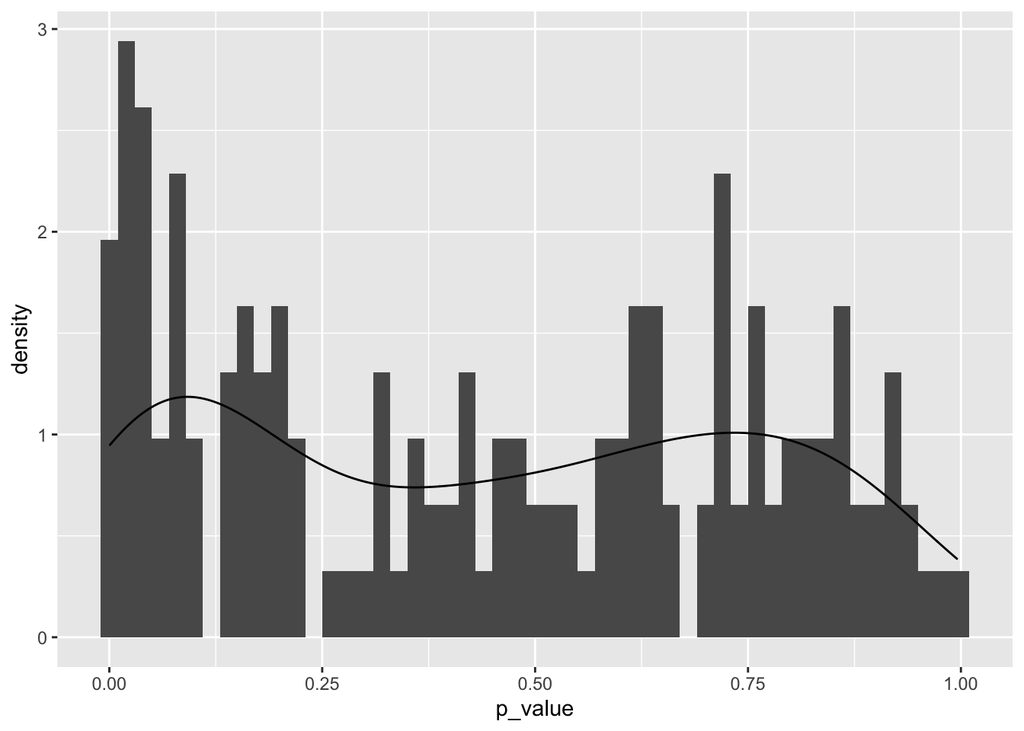

## Table 1: Top 25 era-adjusted BA, OBP, HR, bWAR and fWAR leaders in the manuscript

| rank | name | BA | name | OBP | name | HR |
| --- | --- | --- | --- | --- | --- | --- |
| 1 | Tony Gwynn | 0.342 | Ted Williams | 0.442 | Babe Ruth | 702 |
| 2 | Rod Carew | 0.329 | Mike Trout | 0.438 | Henry Aaron | 689 |
| 3 | Jose Altuve | 0.327 | Barry Bonds | 0.434 | Albert Pujols | 662 |
| 4 | Ichiro Suzuki | 0.327 | Joey Votto | 0.433 | Barry Bonds | 654 |
| 5 | Miguel Cabrera | 0.32 | Babe Ruth | 0.426 | Reggie Jackson | 578 |
| 6 | Roberto Clemente | 0.32 | Mickey Mantle | 0.42 | Willie Mays | 577 |
| 7 | Ty Cobb | 0.32 | Bryce Harper | 0.417 | Mike Schmidt | 561 |
| 8 | Joe DiMaggio | 0.318 | Lou Gehrig | 0.415 | Alex Rodriguez | 547 |
| 9 | Wade Boggs | 0.316 | Frank Thomas | 0.411 | Frank Robinson | 535 |
| 10 | Buster Posey | 0.316 | Freddie Freeman | 0.41 | Ken Griffey Jr | 528 |
| 11 | Mike Trout | 0.315 | Edgar Martinez | 0.41 | Willie Stargell | 528 |
| 12 | Freddie Freeman | 0.314 | Lance Berkman | 0.407 | David Ortiz | 521 |
| 13 | Joe Mauer | 0.314 | Paul Goldschmidt | 0.407 | Willie McCovey | 515 |
| 14 | Ted Williams | 0.314 | Wade Boggs | 0.405 | Harmon Killebrew | 508 |
| 15 | Stan Musial | 0.313 | Christian Yelich | 0.405 | Ted Williams | 503 |
| 16 | Willie Mays | 0.312 | Rickey Henderson | 0.404 | Mickey Mantle | 502 |
| 17 | Bill Terry | 0.312 | Jason Giambi | 0.403 | Eddie Mathews | 502 |
| 18 | Robinson Canó | 0.311 | Joe Mauer | 0.403 | Eddie Murray | 498 |
| 19 | Henry Aaron | 0.31 | Miguel Cabrera | 0.402 | Jimmie Foxx | 493 |
| 20 | Matty Alou | 0.31 | Joe Morgan | 0.402 | Stan Musial | 492 |
| 21 | Vladimir Guerrero | 0.31 | Prince Fielder | 0.4 | Dave Winfield | 491 |
| 22 | Derek Jeter | 0.31 | Brian Giles | 0.4 | Mark McGwire | 489 |
| 23 | Al Oliver | 0.31 | Mike Hargrove | 0.4 | Jim Thome | 484 |
| 24 | Lou Gehrig | 0.309 | Manny Ramirez | 0.4 | Miguel Cabrera | 480 |
| 25 | Edgar Martinez | 0.309 | Jeff Bagwell | 0.399 | Lou Gehrig | 479 |
| pre-1950 in top 10 | 2 |  | 3 |  | 1 |  |
| pre-1950 in top 25 | 6 |  | 3 |  | 5 |  |
| proportion before 1950 | 0.259 |  | 0.259 |  | 0.259 |  |
| MLB-eligible population | 1871-2012 |  | 1871-2012 |  | 1871-2012 |  |
| chance in top 10 | 1 in 1.29 |  | 1 in 1.99 |  | 1 in 1.05 |  |
| chance in top 10 | 1 in 1.51 |  | 1 in 1.03 |  | 1 in 1.23 |  |

| rank | name | ebWAR | name | efWAR |
| --- | --- | --- | --- | --- |
| 1 | Barry Bonds | 153.89 | Barry Bonds | 145.24 |
| 2 | Willie Mays | 144.08 | Willie Mays | 135.39 |
| 3 | Henry Aaron | 135.6 | Henry Aaron | 128.05 |
| 4 | Babe Ruth | 127.29 | Babe Ruth | 120.44 |
| 5 | Alex Rodriguez | 120.29 | Stan Musial | 113.03 |
| 6 | Stan Musial | 119.51 | Alex Rodriguez | 110.3 |
| 7 | Ty Cobb | 114.48 | Ty Cobb | 108.77 |
| 8 | Albert Pujols | 111.86 | Ted Williams | 107.75 |
| 9 | Mike Schmidt | 109.58 | Mike Schmidt | 106.41 |
| 10 | Rickey Henderson | 109.08 | Rickey Henderson | 103.9 |
| 11 | Ted Williams | 107.86 | Albert Pujols | 97.34 |
| 12 | Tris Speaker | 102.26 | Joe Morgan | 96.07 |
| 13 | Joe Morgan | 100.17 | Frank Robinson | 95.92 |
| 14 | Frank Robinson | 99.93 | Mel Ott | 95.72 |
| 15 | Mel Ott | 99.74 | Tris Speaker | 95.13 |
| 16 | Cal Ripken Jr | 97.39 | Rogers Hornsby | 94.42 |
| 17 | Rogers Hornsby | 97.01 | Mickey Mantle | 94.3 |
| 18 | Lou Gehrig | 95.87 | Cal Ripken Jr | 93.24 |
| 19 | Mickey Mantle | 95.37 | Lou Gehrig | 92.98 |
| 20 | Carl Yastrzemski | 95.2 | Carl Yastrzemski | 92.64 |
| 21 | Adrián Beltré | 95.01 | Honus Wagner | 89.81 |
| 22 | Wade Boggs | 92.51 | Wade Boggs | 87.91 |
| 23 | Roberto Clemente | 91.37 | Mike Trout | 87.87 |
| 24 | Eddie Collins | 90.94 | Eddie Mathews | 86.38 |
| 25 | Mike Trout | 90.43 | Adrián Beltré | 86.34 |
| pre-1950 in top 10 | 3 |  | 4 |  |
| pre-1950 in top 25 | 9 |  | 9 |  |
| proportion before 1950 | 0.263 |  | 0.263 |  |
| chance in top 10 | 1 in 1.95 |  | 1 in 3.92 |  |
| chance in top 10 | 1 in 5.31 |  | 1 in 5.31 |  |

## Table 2: Top 25 era-adjusted IP, ERA, SO. bWAR and fWAR leaders in the manuscript.

| rank | name | IP | name | ERA | name | SO |
| --- | --- | --- | --- | --- | --- | --- |
| 1 | Greg Maddux | 5646 | Clayton Kershaw | 2.43 | Nolan Ryan | 6026 |
| 2 | Roger Clemens | 5456 | Pedro Martinez | 2.61 | Randy Johnson | 5136 |
| 3 | Nolan Ryan | 5319 | Greg Maddux | 2.77 | Roger Clemens | 4752 |
| 4 | Warren Spahn | 5112 | Lefty Grove | 2.78 | Steve Carlton | 4221 |
| 5 | Phil Niekro | 5082 | Roger Clemens | 2.81 | Walter Johnson | 3888 |
| 6 | Don Sutton | 5071 | Justin Verlander | 2.81 | Bert Blyleven | 3785 |
| 7 | Gaylord Perry | 4977 | Max Scherzer | 2.83 | Tom Seaver | 3656 |
| 8 | Tom Glavine | 4917 | Roy Halladay | 2.85 | Don Sutton | 3575 |
| 9 | Bert Blyleven | 4877 | Randy Johnson | 2.9 | Max Scherzer | 3506 |
| 10 | Steve Carlton | 4816 | Tom Seaver | 2.91 | Greg Maddux | 3473 |
| 11 | Walter Johnson | 4791 | Cole Hamels | 2.94 | Gaylord Perry | 3366 |
| 12 | Randy Johnson | 4724 | Carl Hubbell | 2.94 | Phil Niekro | 3364 |
| 13 | Cy Young | 4663 | Whitey Ford | 2.96 | Justin Verlander | 3297 |
| 14 | Tom Seaver | 4587 | Curt Schilling | 2.96 | Pedro Martinez | 3113 |
| 15 | Tommy John | 4585 | John Smoltz | 2.96 | John Smoltz | 3106 |
| 16 | Jamie Moyer | 4585 | Bob Gibson | 2.97 | Bob Feller | 3104 |
| 17 | Robin Roberts | 4435 | Jim Palmer | 2.97 | Fergie Jenkins | 3088 |
| 18 | Pete Alexander | 4356 | Zack Greinke | 3.01 | Curt Schilling | 3036 |
| 19 | Zack Greinke | 4278 | Tim Hudson | 3.03 | Clayton Kershaw | 2980 |
| 20 | Early Wynn | 4277 | Juan Marichal | 3.05 | CC Sabathia | 2960 |
| 21 | Fergie Jenkins | 4199 | Steve Carlton | 3.07 | Warren Spahn | 2955 |
| 22 | Dennis Martinez | 4182 | Tom Glavine | 3.1 | Zack Greinke | 2916 |
| 23 | CC Sabathia | 4169 | Félix Hernández | 3.1 | Frank Tanana | 2849 |
| 24 | Justin Verlander | 4107 | Kevin Brown | 3.12 | Bob Gibson | 2836 |
| 25 | Jack Morris | 4039 | Adam Wainwright | 3.12 | Lefty Grove | 2826 |
| pre-1950 in top 10 | 1 |  | 1 |  | 1 |  |
| pre-1950 in top 25 | 6 |  | 2 |  | 4 |  |
| proportion before 1950 | 0.298 |  | 0.28 |  | 0.28 |  |
| MLB-eligible population | 1871-2006 |  | 1871-2012 |  | 1871-2006 |  |
| chance in top 10 | 1 in 1.03 |  | 1 in 1.04 |  | 1 in 1.04 |  |
| chance in top 10 | 1 in 1.25 |  | 1 in 1 |  | 1 in 1.05 |  |

| rank | name | ebWAR | name | efWAR |
| --- | --- | --- | --- | --- |
| 1 | Roger Clemens | 145.88 | Roger Clemens | 141.25 |
| 2 | Greg Maddux | 113.66 | Greg Maddux | 120.73 |
| 3 | Randy Johnson | 110.81 | Randy Johnson | 109.77 |
| 4 | Tom Seaver | 104.31 | Nolan Ryan | 108.3 |
| 5 | Lefty Grove | 102.54 | Bert Blyleven | 101.82 |
| 6 | Justin Verlander | 100.23 | Steve Carlton | 100.34 |
| 7 | Bert Blyleven | 97.69 | Lefty Grove | 98.8 |
| 8 | Phil Niekro | 94.37 | Justin Verlander | 95.07 |
| 9 | Clayton Kershaw | 93.78 | Gaylord Perry | 94.45 |
| 10 | Walter Johnson | 91.53 | Walter Johnson | 91.8 |
| 11 | Warren Spahn | 91.2 | Cy Young | 91.28 |
| 12 | Max Scherzer | 90.63 | Tom Seaver | 90.78 |
| 13 | Zack Greinke | 90.23 | Clayton Kershaw | 88.83 |
| 14 | Gaylord Perry | 89.5 | Don Sutton | 82.98 |
| 15 | Steve Carlton | 88.7 | Max Scherzer | 82.14 |
| 16 | Pedro Martinez | 87.2 | Pedro Martinez | 82.13 |
| 17 | Nolan Ryan | 86.85 | Zack Greinke | 80.28 |
| 18 | Mike Mussina | 84.62 | Mike Mussina | 80.08 |
| 19 | Curt Schilling | 82.09 | John Smoltz | 79.36 |
| 20 | Tom Glavine | 81.89 | Pete Alexander | 77.55 |
| 21 | Robin Roberts | 79.01 | Phil Niekro | 77.47 |
| 22 | Fergie Jenkins | 77.83 | Curt Schilling | 77 |
| 23 | Bob Gibson | 77 | Bob Gibson | 76.45 |
| 24 | Roy Halladay | 76.07 | Fergie Jenkins | 75.97 |
| 25 | CC Sabathia | 74.5 | Tommy John | 75.8 |
| pre-1950 in top 10 | 2 |  | 2 |  |
| pre-1950 in top 25 | 4 |  | 4 |  |
| proportion before 1950 | 0.28 |  | 0.28 |  |
| chance in top 10 | 1 in 1.22 |  | 1 in 1.22 |  |
| chance in top 10 | 1 in 1.05 |  | 1 in 1.05 |  |

## Table 3: Top 25 careers according to era-adjusted bWAR (ebWAR), era-adjusted fWAR (efWAR), era-adjusted JAWS computed using bWAR (ebJAWS), and era-adjusted JAWS computed using fWAR (efJAWS).

| name | ebWAR | name | ebJAWS | name | efWAR | name | efJAWS |
| --- | --- | --- | --- | --- | --- | --- | --- |
| Barry Bonds | 153.89 | Barry Bonds | 109.14 | Barry Bonds | 145.24 | Barry Bonds | 107.14 |
| Roger Clemens | 145.88 | Roger Clemens | 107.47 | Roger Clemens | 141.25 | Roger Clemens | 103.54 |
| Willie Mays | 144.08 | Babe Ruth | 106.04 | Willie Mays | 135.39 | Willie Mays | 98.72 |
| Henry Aaron | 135.60 | Willie Mays | 105.16 | Henry Aaron | 128.05 | Babe Ruth | 90.29 |
| Babe Ruth | 127.29 | Henry Aaron | 95.11 | Greg Maddux | 120.73 | Henry Aaron | 89.52 |
| Alex Rodriguez | 120.29 | Alex Rodriguez | 91.66 | Babe Ruth | 120.44 | Greg Maddux | 88.51 |
| Stan Musial | 119.51 | Stan Musial | 88.38 | Stan Musial | 113.03 | Randy Johnson | 85.78 |
| Ty Cobb | 114.48 | Randy Johnson | 88.20 | Alex Rodriguez | 110.30 | Alex Rodriguez | 84.35 |
| Greg Maddux | 113.66 | Albert Pujols | 86.33 | Randy Johnson | 109.77 | Stan Musial | 83.61 |
| Albert Pujols | 111.86 | Greg Maddux | 85.60 | Ty Cobb | 108.77 | Ted Williams | 82.72 |
| Randy Johnson | 110.81 | Mike Schmidt | 84.52 | Nolan Ryan | 108.30 | Mike Schmidt | 82.20 |
| Mike Schmidt | 109.58 | Lefty Grove | 84.52 | Ted Williams | 107.75 | Lefty Grove | 79.31 |
| Rickey Henderson | 109.08 | Ted Williams | 83.54 | Mike Schmidt | 106.41 | Ty Cobb | 78.85 |
| Ted Williams | 107.86 | Ty Cobb | 82.62 | Rickey Henderson | 103.90 | Rickey Henderson | 78.83 |
| Tom Seaver | 104.31 | Rickey Henderson | 82.14 | Bert Blyleven | 101.82 | Steve Carlton | 78.32 |
| Lefty Grove | 102.54 | Justin Verlander | 80.34 | Steve Carlton | 100.34 | Nolan Ryan | 76.89 |
| Tris Speaker | 102.26 | Lou Gehrig | 79.22 | Lefty Grove | 98.80 | Lou Gehrig | 76.88 |
| Justin Verlander | 100.23 | Joe Morgan | 79.03 | Albert Pujols | 97.34 | Albert Pujols | 75.80 |
| Joe Morgan | 100.17 | Tom Seaver | 78.51 | Joe Morgan | 96.07 | Justin Verlander | 75.29 |
| Frank Robinson | 99.93 | Cal Ripken Jr | 77.54 | Frank Robinson | 95.92 | Joe Morgan | 75.14 |
| Mel Ott | 99.74 | Mike Trout | 77.26 | Mel Ott | 95.72 | Bert Blyleven | 75.12 |
| Bert Blyleven | 97.69 | Rogers Hornsby | 76.61 | Tris Speaker | 95.13 | Rogers Hornsby | 74.27 |
| Cal Ripken Jr | 97.39 | Wade Boggs | 75.61 | Justin Verlander | 95.07 | Mike Trout | 73.90 |
| Rogers Hornsby | 97.01 | Clayton Kershaw | 75.12 | Gaylord Perry | 94.45 | Mickey Mantle | 73.71 |
| Lou Gehrig | 95.87 | Mickey Mantle | 75.09 | Rogers Hornsby | 94.42 | Cal Ripken Jr | 73.62 |

## Histogram of the best 100 and 1000 players by their rookie year

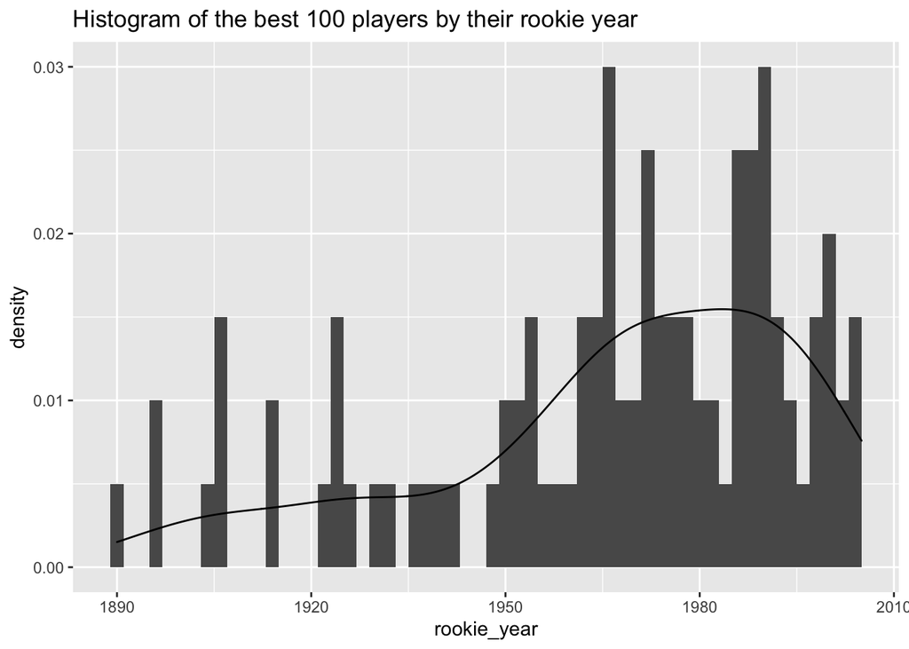

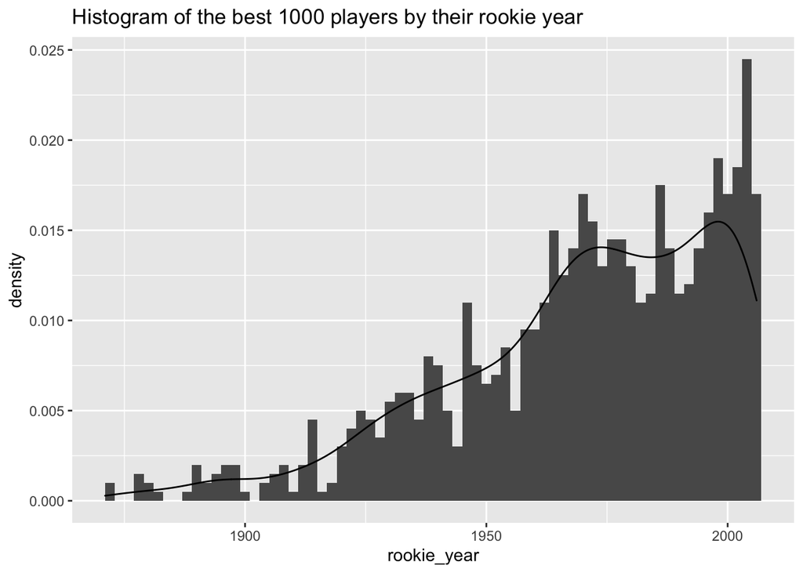

# Discussion

## Year Effect on the Talent of the Replacement-level Batters

The year effect for bWAR from the talent perspective and the era-adjusted bWAR perspective will be covered in this section.

The two figures below show that the bWAR and fWAR talent of the replacement-level batters from 1871 to 2023 The line in the plot is the smoothed line after apply natural cubic spline method. The changing pattern is the similar for the talent of the replacement-level batters and MLB-eligible population. The seasons that deviate from the smoothed line are those associated with strikes and World War II, such as 1943 - 1946, 1981, 1994, 1995 and 2020 seasons.

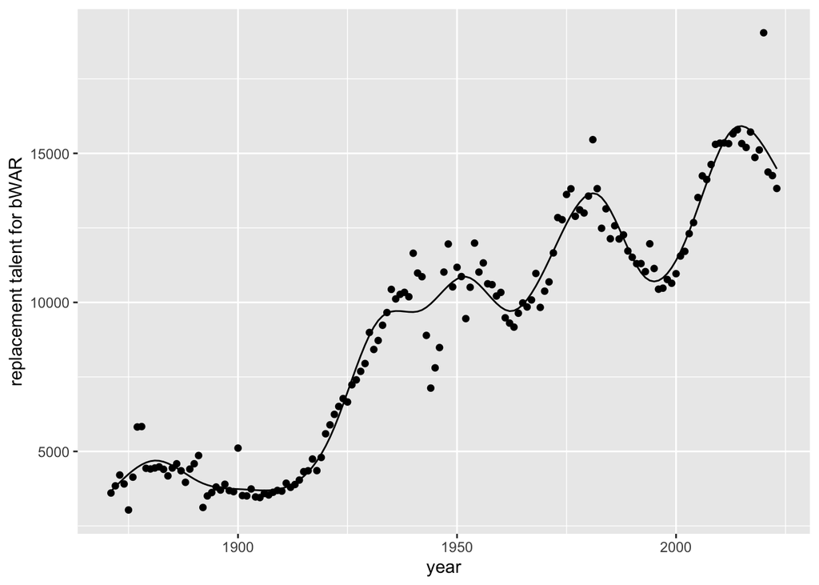

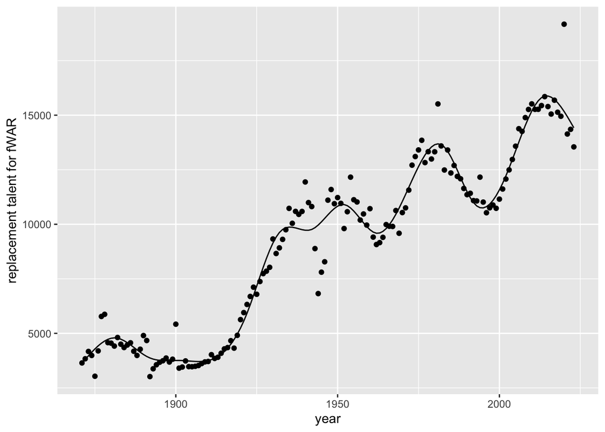

## Year Effect on the Era-adjusted WAR of the Hypothetical Batters from 2023

In this section we calculate the bWAR talent of a hypothetical 2023 hitter with 0 bWAR. Then, we compute his era-adjusted bWAR by mapping this hypothetical player to the other seasons from 1871 through 2023.

## Figure 2: Year Effect on the Era-adjusted WAR in the paper.

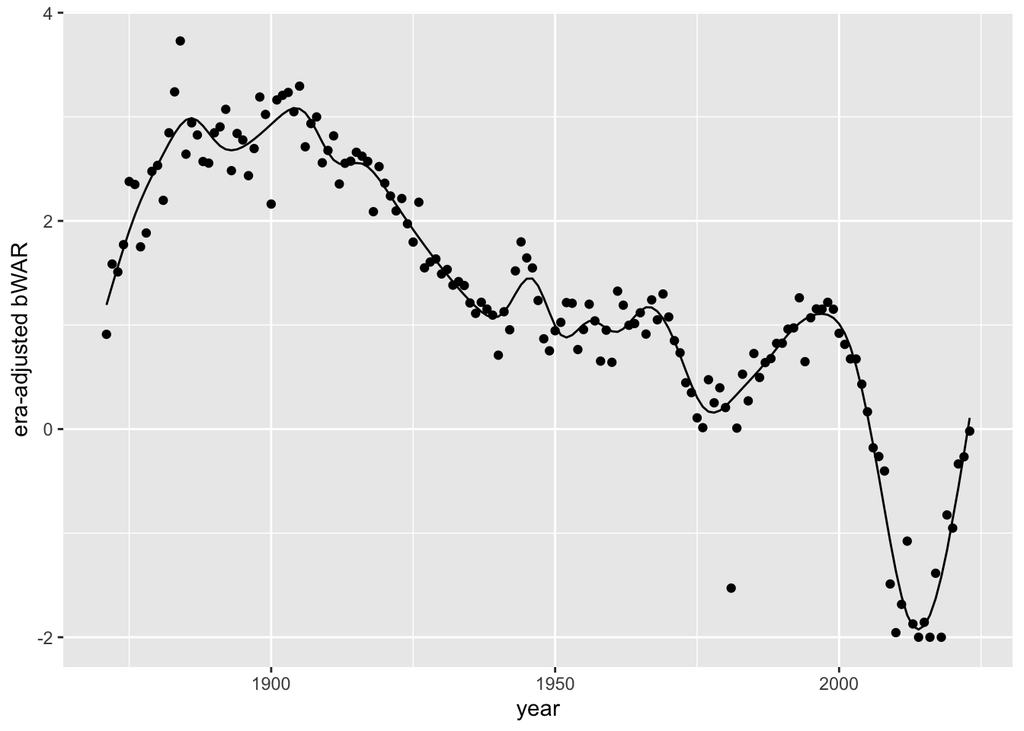

The figure above shows the era-adjusted bWAR values over time corresponding to a hypothetical batter with 0 bWAR in 2023 using the Full House Model. The fall in the mid-2000s corresponds to increase of MLB-eligible population. Despite the sharp decline in era-adjusted bWAR values in 1981 season, it is untrue that the 1981 batters with 0 bWAR would perform better than the 2023 batters. This is because the 1981 season was brief and a large number of batters underperformed replacement-level players. The problem of the sharp decline in era-adjusted bWAR values in the 1981 season is resolved when we look at the era-adjusted bWAR and era-adjusted bWAR per game of the hypothetical hitters from 2023 with 2 bWAR.

The two figures below shows the era-adjusted bWAR and era-adjusted bWAR per game of the hypothetical hitters from 2023 with 2 bWAR.

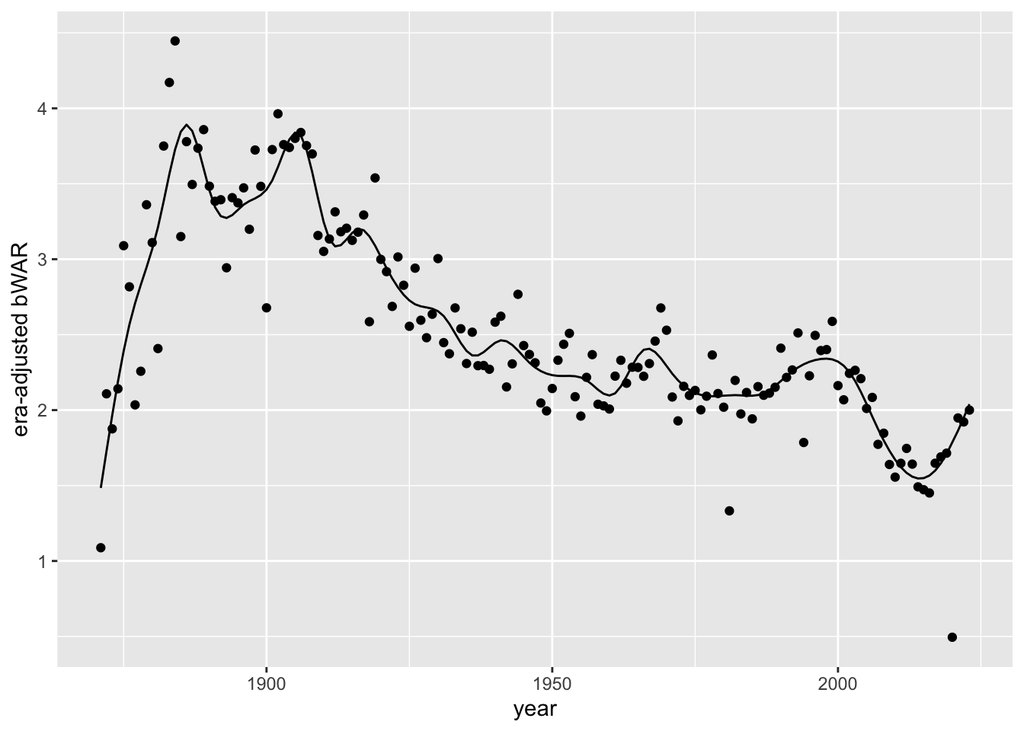

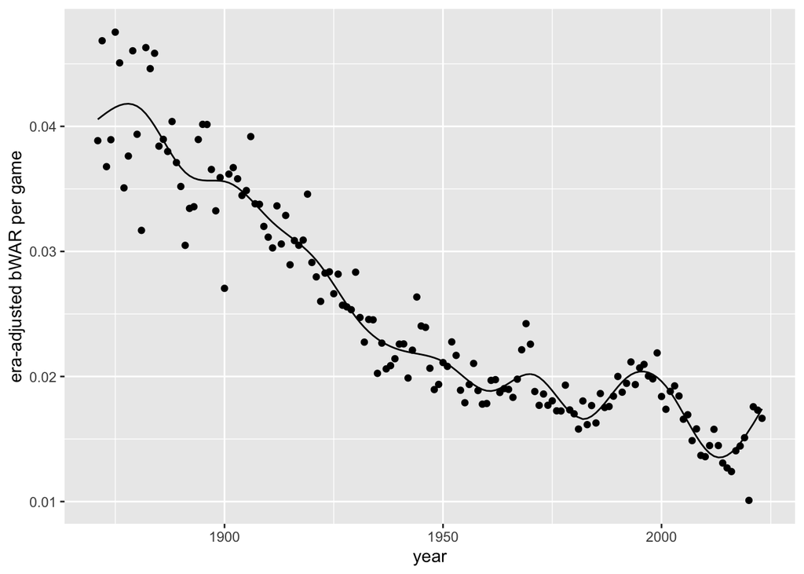

Then we also calculate the fWAR talent of a hypothetical 2023 hitter with 0 fWAR. Then, we compute his era-adjusted fWAR by mapping this hypothetical player to the other seasons from 1871 through 2023.

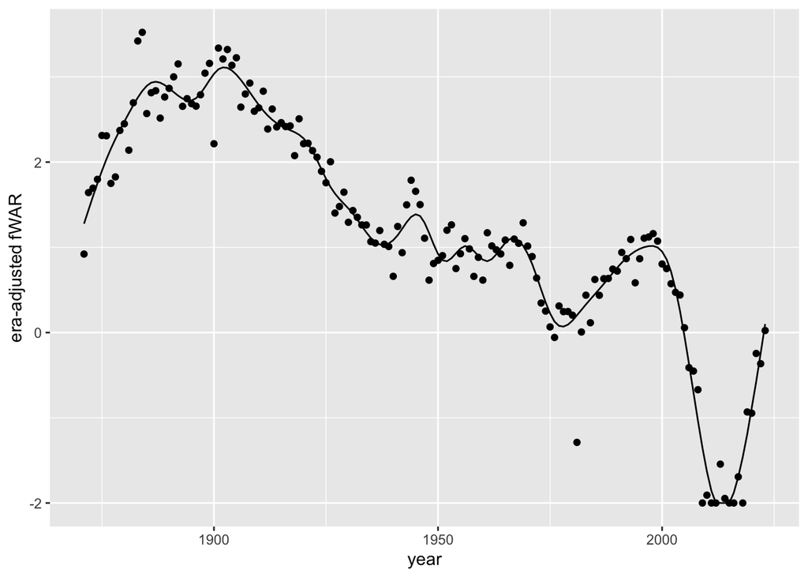

The figure above shows the era-adjusted fWAR values over time corresponding to a hypothetical batter with 0 fWAR in 2023 using the Full House Model. The fall in the mid-2000s corresponds to increase of MLB-eligible population. The problem of the sharp decline in era-adjusted fWAR values in the 1981 season can also be resolved when we look at the era-adjusted fWAR and era-adjusted fWAR per game of the hypothetical hitters from 2023 with 2 fWAR.

The two figures below show he era-adjusted fWAR and era-adjusted fWAR per game of the hypothetical hitters from 2023 with 2 fWAR.

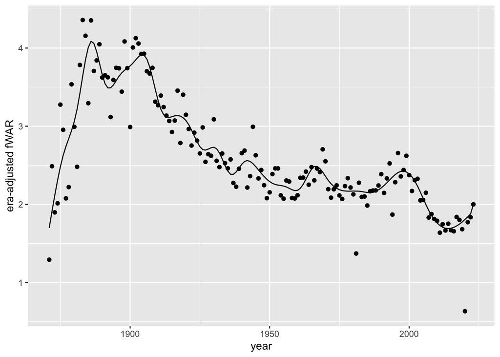

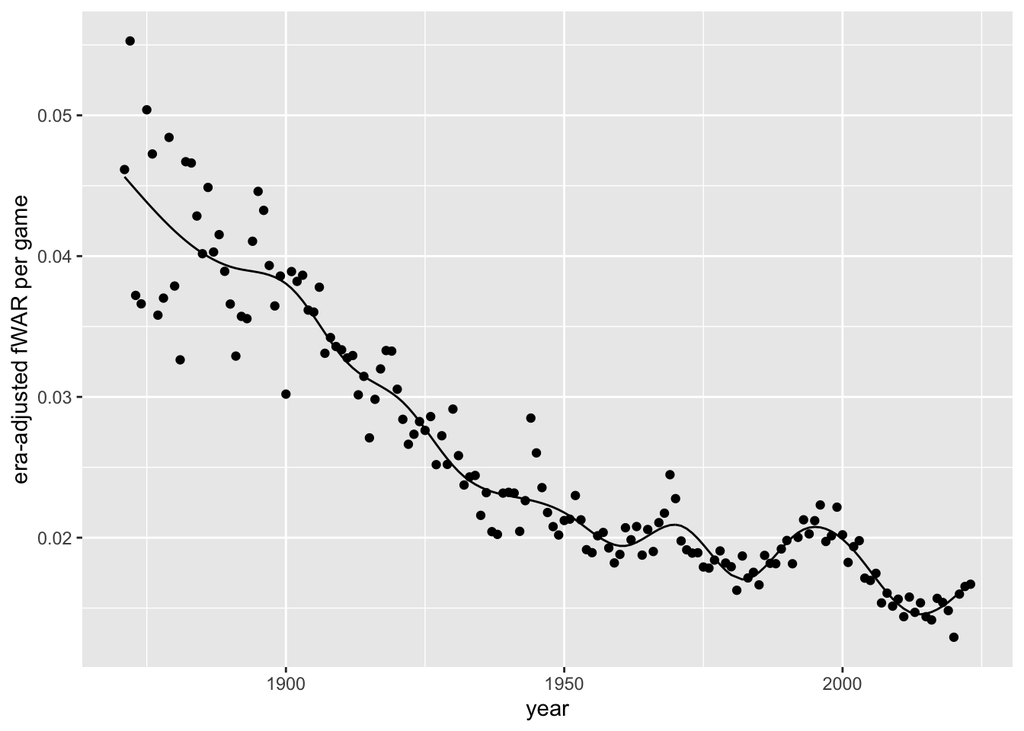

## Expansion Effect

It is actually supposed that the Major League’s expansion effect has a significant impact on how the talent scores vary over time and the magnitude of talent will be diluted with the expansion. However, after adding some hypothetical players who had poor performance in the early seasons, when there were fewer players, we discover that the real players did not much benefit from the adjustment of adding hypothetical players. Additionally, we make an effort to establish replacement player baselines throughout all seasons and adjust these baselines at the same level. However, the baselines we construct for every season are quite similar, and the talents of the players from earlier eras do not get much improved.

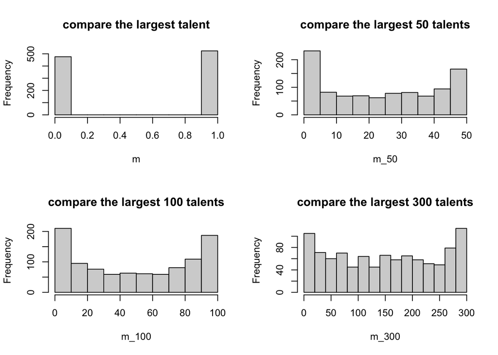

We also run another simulation to test the effect of season size. Instead of generating 600 components in the group 1, I generate 900 components and repeat the rest of the simulation. Then we have the similar results.

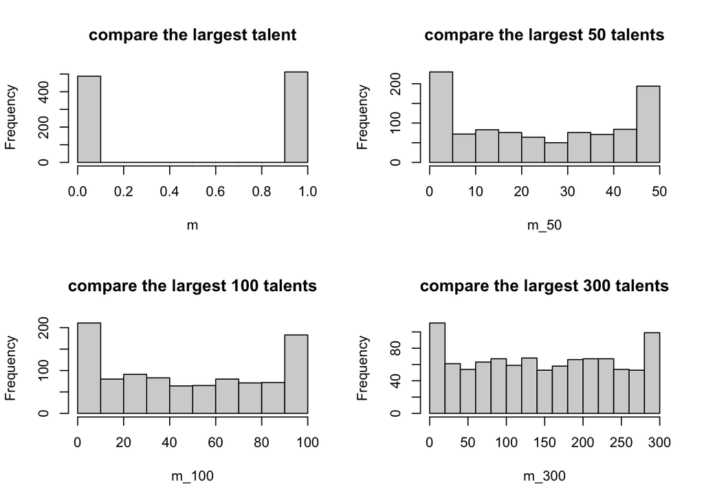

In this part, we compare the BA before and in the expansion seasons and see if there is a significant difference between them. The expansion seasons are collected from [Wikipedia](https://en.wikipedia.org/wiki/Major_League_Baseball) and they are 1879, 1892, 1900, 1901, 1961, 1962, 1969, 1977, 1993, and 1998. We compute the average and standard deviation of full-time batters’ BA before and in the expansion seasons and the results are shown below.

| yearID | mean | sd | yearID | mean | sd |
| --- | --- | --- | --- | --- | --- |
| 1878 | 0.281 | 0.043 | 1879 | 0.270 | 0.041 |
| 1891 | 0.264 | 0.027 | 1892 | 0.259 | 0.029 |
| 1899 | 0.293 | 0.037 | 1900 | 0.291 | 0.034 |
| 1900 | 0.291 | 0.034 | 1901 | 0.284 | 0.039 |
| 1960 | 0.268 | 0.025 | 1961 | 0.272 | 0.029 |
| 1961 | 0.272 | 0.029 | 1962 | 0.271 | 0.026 |
| 1968 | 0.250 | 0.027 | 1969 | 0.261 | 0.029 |
| 1976 | 0.264 | 0.030 | 1977 | 0.273 | 0.028 |
| 1992 | 0.265 | 0.026 | 1993 | 0.276 | 0.028 |
| 1997 | 0.276 | 0.027 | 1998 | 0.276 | 0.027 |

The average and standard error of the difference between the full-time batters’ BA before and in the expansion seasons are shown below.

| avg | se |
| --- | --- |
| -9e-04 | 0.0024288 |

We also show Willie Mays’s seasonal bWAR per game in his 22 years MLB career from 1951 to 1973 season except the 1953 season. The red dots represent the seasons that the MLB were experiencing the expansion. The result show that the expansion did not have any significant positive or negative effects on Willie Mays’s prime season or the tail of his career.

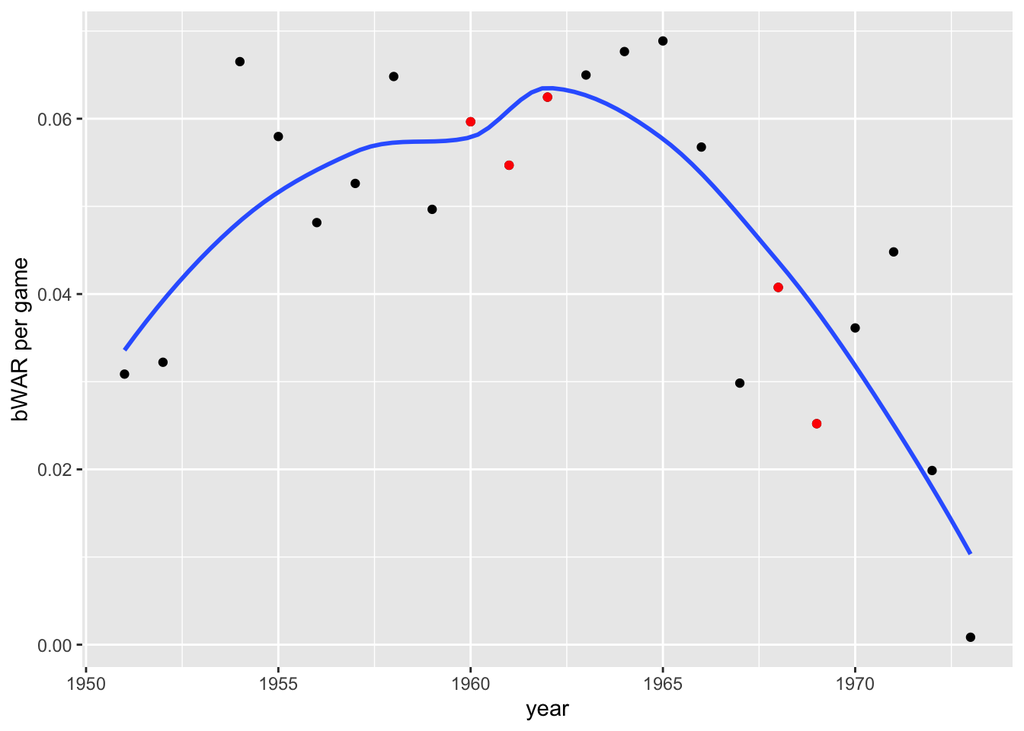

We also show Randy Johnson’s seasonal bWAR per game in his 22 years MLB career from 1988 to 2009 season. The red dots represent the seasons that the MLB were experiencing the expansion. The result show that the expansion did not have any significant positive or negative effects on Randy Johnson’s prime season.

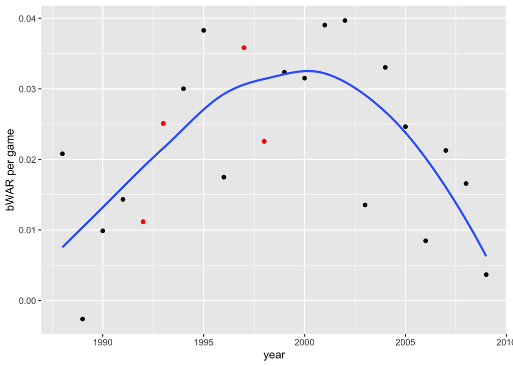

## Figure 3: 4 moments of BA in paper

This figure below shows that four statistical moments of the batting average distribution from 1871 to 2021 season. Points in red correspond to seasons surrounding the peak of WWII (1941-1946).

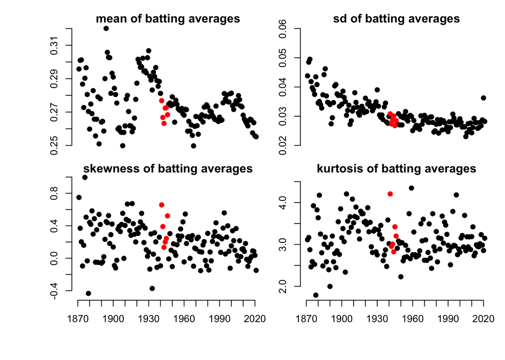

## Distribution Sensitity Analysis

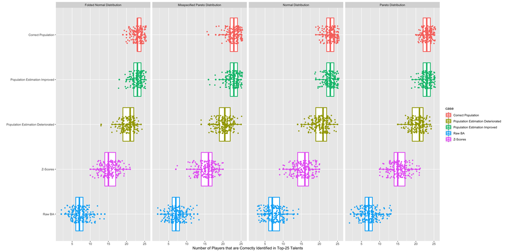

## Table 8: Comparsion between deteriorated estimation regime and Z-scores in the Supplementary materials.

|  | correct Pareto dist | incorrect Pareto dist | normal dist | folded normal dist |
| --- | --- | --- | --- | --- |
| beat or ties | 1 | 1 | 1.000 | 1 |
| strictly beat | 1 | 1 | 0.995 | 1 |

## Table 9: bWAR rankings from Full House Model using different talent generating function in the Supplementary materials.

In this section, we use different talent generating process to verify the robustness of the model.

The table below shows the top 25 bWAR players using four different talent generating process. The talent follows folded normal distribution, normal distribution, Pareto distribution with $\alpha = 3$ and Pareto distribution with $\alpha = 1.16$. Given that the ranking lists produced by the four separate generating processes are identical, we can say that our Full House model’s talent generating process is fairly robust.

| rank | standard normal | Folded normal (mu = 0, sigma = 1) | Pareto with alpha = 3 | Pareto with alpha = 1.16 |
| --- | --- | --- | --- | --- |
| 1 | Barry Bonds | Barry Bonds | Barry Bonds | Barry Bonds |
| 2 | Roger Clemens | Roger Clemens | Roger Clemens | Roger Clemens |
| 3 | Willie Mays | Willie Mays | Willie Mays | Willie Mays |
| 4 | Henry Aaron | Henry Aaron | Henry Aaron | Henry Aaron |
| 5 | Babe Ruth | Babe Ruth | Babe Ruth | Babe Ruth |
| 6 | Stan Musial | Stan Musial | Stan Musial | Stan Musial |
| 7 | Alex Rodriguez | Alex Rodriguez | Alex Rodriguez | Alex Rodriguez |
| 8 | Greg Maddux | Greg Maddux | Greg Maddux | Greg Maddux |
| 9 | Ty Cobb | Ty Cobb | Ty Cobb | Ty Cobb |
| 10 | Randy Johnson | Randy Johnson | Randy Johnson | Randy Johnson |
| 11 | Mike Schmidt | Mike Schmidt | Mike Schmidt | Mike Schmidt |
| 12 | Albert Pujols | Albert Pujols | Albert Pujols | Albert Pujols |
| 13 | Rickey Henderson | Rickey Henderson | Rickey Henderson | Rickey Henderson |
| 14 | Ted Williams | Ted Williams | Ted Williams | Ted Williams |
| 15 | Tom Seaver | Tom Seaver | Tom Seaver | Tom Seaver |
| 16 | Lefty Grove | Lefty Grove | Lefty Grove | Lefty Grove |
| 17 | Tris Speaker | Tris Speaker | Tris Speaker | Tris Speaker |
| 18 | Joe Morgan | Joe Morgan | Joe Morgan | Joe Morgan |
| 19 | Frank Robinson | Frank Robinson | Frank Robinson | Frank Robinson |
| 20 | Bert Blyleven | Bert Blyleven | Bert Blyleven | Bert Blyleven |
| 21 | Cal Ripken Jr | Cal Ripken Jr | Cal Ripken Jr | Cal Ripken Jr |
| 22 | Mel Ott | Mel Ott | Mel Ott | Mel Ott |
| 23 | Rogers Hornsby | Rogers Hornsby | Rogers Hornsby | Rogers Hornsby |
| 24 | Lou Gehrig | Lou Gehrig | Lou Gehrig | Lou Gehrig |
| 25 | Mickey Mantle | Mickey Mantle | Mickey Mantle | Mickey Mantle |

## Z-scores for 1997 Gwynn and 1911 Cobb from park factor adjusted BAs and regular unadjusted BAs.

| name | year | zscore_BA | normality_BA | zscore_obs_BA | normality_obs_BA |
| --- | --- | --- | --- | --- | --- |
| Ty Cobb | 1911 | 3.425657 | 0.1625329 | 3.460512 | 0.0436831 |
| Tony Gwynn | 1997 | 3.822984 | 0.0167243 | 3.339753 | 0.1744079 |

## MLB-eligible population Calculation

Based on the MLB-eligible population computed from the supplementary materials, we are able to obtain the proportion of the MLB-eligible population before 1950 in different season spans. For example, we would like to calculate the proportion of the MLB-eligible population before 1950 from 1871 to 2006. Given the MLB-eligible population are evenly distribution from the age 20 to 29, the cumulative MLB-eligible males aged 20 to 29 from 1871 to 1879 is equal to 90% of the MLB-eligible population in 1871. Similarly, the cumulative MLB-eligible males aged 20 to 29 from 2000 to 2006 is equal to 60% of the MLB-eligible population in 2006. The code below shows how to compute the proportion of the MLB-eligible population before 1950 from 1871 to 2006.

```r
MLBpops <- bat_dat %>% group_by(yearID) %>% summarise(pops = unique(pops)) %>% group_by(yearID) %>%
  summarise(population = round(mean(pops), 2))
```

```r
# MLBpops contains the MLB-eligible population from 1871 to 2006
n <- MLBpops[MLBpops$yearID %in% c(1871, seq(1880, 2000, 10), 2006),]
p <- n
p$population[1] <- n$population[1] /10*9
p$population[15] <- n$population[15] /10*6
o <- p %>% mutate(population = round(population, 2)) %>%
  mutate(cpp = round(cumsum(p$population)/(sum(p$population)), 3))

kable(o[o$yearID == 1950,c(1,3)]) %>%
  kable_styling(bootstrap_options = c("striped", "hover", "condensed", "responsive"))
```

| yearID | cpp |
| --- | --- |
| 1950 | 0.292 |

## Top 25 bWAR and fWAR leaders for MLB players with era-adjusted bWAR and fWAR

| name | ebWAR | name | efWAR |
| --- | --- | --- | --- |
| Barry Bonds | 153.89 | Barry Bonds | 145.24 |
| Roger Clemens | 145.88 | Roger Clemens | 141.25 |
| Willie Mays | 144.08 | Willie Mays | 135.39 |
| Babe Ruth | 137.98 | Henry Aaron | 128.05 |
| Henry Aaron | 135.60 | Greg Maddux | 120.73 |
| Alex Rodriguez | 120.29 | Babe Ruth | 120.28 |
| Stan Musial | 119.51 | Stan Musial | 113.03 |
| Ty Cobb | 114.48 | Alex Rodriguez | 110.30 |
| Greg Maddux | 113.66 | Randy Johnson | 109.77 |
| Albert Pujols | 111.86 | Ty Cobb | 108.77 |
| Randy Johnson | 110.81 | Nolan Ryan | 108.30 |
| Mike Schmidt | 109.58 | Ted Williams | 107.75 |
| Rickey Henderson | 109.08 | Mike Schmidt | 106.41 |
| Ted Williams | 107.86 | Rickey Henderson | 103.90 |
| Tom Seaver | 104.31 | Bert Blyleven | 101.82 |
| Lefty Grove | 102.54 | Steve Carlton | 100.34 |
| Tris Speaker | 102.26 | Lefty Grove | 98.80 |
| Justin Verlander | 100.23 | Albert Pujols | 97.34 |
| Joe Morgan | 100.17 | Joe Morgan | 96.07 |
| Frank Robinson | 99.93 | Frank Robinson | 95.92 |
| Mel Ott | 99.74 | Mel Ott | 95.72 |
| Bert Blyleven | 97.69 | Tris Speaker | 95.13 |
| Cal Ripken Jr | 97.39 | Justin Verlander | 95.07 |
| Rogers Hornsby | 97.01 | Gaylord Perry | 94.45 |
| Lou Gehrig | 95.87 | Rogers Hornsby | 94.42 |

## Sensitivity Analysis for the condition where some talented potential baseball players fail to start their sports career in baseball.

In this section, we perform a sensitivity analysis for the condition where some talented potential baseball players fail to start their sports career in baseball. For example, people argue that Kyler Murray and Pat Mahomes are playing in the NFL, but they are also considered as the two of the most talented potential baseball players. Competition from other sports is fierce at the upper end of the talent pool where multiple sport opportunities are common.

In this sensitivity analysis, we assume the 10th, 20th, …, 100th talented potential baseball players fail to start their sports career in baseball, which indicates the player with 10th largest bWAR or fWAR is paired with 11th largest talent, the player with 20th largest bWAR or fWAR is paired with 22th largest talent, and so on. Then we mapped their talents into the common mapping environment we build before and compute the era-adjusted bWAR and fWAR. We perform this analysis for the seasons after 1950 season based on the effect of baseball integration. We also perform this analysis for the seasons after 1994 season based on the effect of MLB strike.

The tables below are the top 25 ebWAR and efWAR for batters and pitchers combined with respect to this sensitivity analysis.

| without rm | ebWAR | rm after 1950 | ebWAR | rm after 1994 | ebWAR |
| --- | --- | --- | --- | --- | --- |
| Barry Bonds | 153.89 | Barry Bonds | 153.89 | Barry Bonds | 153.89 |
| Roger Clemens | 145.88 | Roger Clemens | 145.88 | Roger Clemens | 145.88 |
| Willie Mays | 144.08 | Willie Mays | 144.08 | Willie Mays | 144.08 |
| Babe Ruth | 137.98 | Babe Ruth | 137.98 | Babe Ruth | 137.98 |
| Henry Aaron | 135.60 | Henry Aaron | 135.60 | Henry Aaron | 135.60 |
| Alex Rodriguez | 120.29 | Alex Rodriguez | 120.29 | Alex Rodriguez | 120.29 |
| Stan Musial | 119.51 | Stan Musial | 119.51 | Stan Musial | 119.51 |
| Ty Cobb | 114.48 | Ty Cobb | 114.48 | Ty Cobb | 114.48 |
| Greg Maddux | 113.66 | Greg Maddux | 113.66 | Greg Maddux | 113.66 |
| Albert Pujols | 111.86 | Albert Pujols | 111.86 | Albert Pujols | 111.86 |
| Randy Johnson | 110.81 | Randy Johnson | 110.81 | Randy Johnson | 110.81 |
| Mike Schmidt | 109.58 | Mike Schmidt | 109.58 | Mike Schmidt | 109.58 |
| Rickey Henderson | 109.08 | Rickey Henderson | 109.08 | Rickey Henderson | 109.08 |
| Ted Williams | 107.86 | Ted Williams | 107.86 | Ted Williams | 107.86 |
| Tom Seaver | 104.31 | Tom Seaver | 104.31 | Tom Seaver | 104.31 |
| Lefty Grove | 102.54 | Lefty Grove | 102.54 | Lefty Grove | 102.54 |
| Tris Speaker | 102.26 | Tris Speaker | 102.26 | Tris Speaker | 102.26 |
| Justin Verlander | 100.23 | Justin Verlander | 100.23 | Justin Verlander | 100.23 |
| Joe Morgan | 100.17 | Joe Morgan | 100.17 | Joe Morgan | 100.17 |
| Frank Robinson | 99.93 | Frank Robinson | 99.93 | Frank Robinson | 99.93 |
| Mel Ott | 99.74 | Mel Ott | 99.74 | Mel Ott | 99.74 |
| Bert Blyleven | 97.69 | Bert Blyleven | 97.69 | Bert Blyleven | 97.69 |
| Cal Ripken Jr | 97.39 | Cal Ripken Jr | 97.39 | Cal Ripken Jr | 97.39 |
| Rogers Hornsby | 97.01 | Rogers Hornsby | 97.01 | Rogers Hornsby | 97.01 |
| Lou Gehrig | 95.87 | Lou Gehrig | 95.87 | Lou Gehrig | 95.87 |

| without rm | efWAR | rm after 1950 | efWAR | rm after 1994 | efWAR |
| --- | --- | --- | --- | --- | --- |
| Barry Bonds | 145.24 | Barry Bonds | 145.24 | Barry Bonds | 145.24 |
| Roger Clemens | 141.25 | Roger Clemens | 141.25 | Roger Clemens | 141.25 |
| Willie Mays | 135.39 | Willie Mays | 135.39 | Willie Mays | 135.39 |
| Henry Aaron | 128.05 | Henry Aaron | 128.05 | Henry Aaron | 128.05 |
| Greg Maddux | 120.73 | Greg Maddux | 120.73 | Greg Maddux | 120.73 |
| Babe Ruth | 120.28 | Babe Ruth | 120.28 | Babe Ruth | 120.28 |
| Stan Musial | 113.03 | Stan Musial | 113.03 | Stan Musial | 113.03 |
| Alex Rodriguez | 110.30 | Alex Rodriguez | 110.30 | Alex Rodriguez | 110.30 |
| Randy Johnson | 109.77 | Randy Johnson | 109.77 | Randy Johnson | 109.77 |
| Ty Cobb | 108.77 | Ty Cobb | 108.77 | Ty Cobb | 108.77 |
| Nolan Ryan | 108.30 | Nolan Ryan | 108.30 | Nolan Ryan | 108.30 |
| Ted Williams | 107.75 | Ted Williams | 107.75 | Ted Williams | 107.75 |
| Mike Schmidt | 106.41 | Mike Schmidt | 106.41 | Mike Schmidt | 106.41 |
| Rickey Henderson | 103.90 | Rickey Henderson | 103.90 | Rickey Henderson | 103.90 |
| Bert Blyleven | 101.82 | Bert Blyleven | 101.82 | Bert Blyleven | 101.82 |
| Steve Carlton | 100.34 | Steve Carlton | 100.34 | Steve Carlton | 100.34 |
| Lefty Grove | 98.80 | Lefty Grove | 98.80 | Lefty Grove | 98.80 |
| Albert Pujols | 97.34 | Albert Pujols | 97.34 | Albert Pujols | 97.34 |
| Joe Morgan | 96.07 | Joe Morgan | 96.07 | Joe Morgan | 96.07 |
| Frank Robinson | 95.92 | Frank Robinson | 95.92 | Frank Robinson | 95.92 |
| Mel Ott | 95.72 | Mel Ott | 95.72 | Mel Ott | 95.72 |
| Tris Speaker | 95.13 | Tris Speaker | 95.13 | Tris Speaker | 95.13 |
| Justin Verlander | 95.07 | Justin Verlander | 95.07 | Justin Verlander | 95.07 |
| Gaylord Perry | 94.45 | Gaylord Perry | 94.45 | Gaylord Perry | 94.45 |
| Rogers Hornsby | 94.42 | Rogers Hornsby | 94.42 | Rogers Hornsby | 94.42 |

The tables below are the top 25 ebJAWS and efJAWS for batters and pitchers combined with respect to this sensitivity analysis.

| without rm | ebJAWS | rm after 1950 | ebJAWS | rm after 1994 | ebJAWS |
| --- | --- | --- | --- | --- | --- |
| Barry Bonds | 109.14 | Barry Bonds | 108.86 | Barry Bonds | 109.01 |
| Roger Clemens | 107.47 | Roger Clemens | 106.80 | Roger Clemens | 107.03 |
| Babe Ruth | 106.04 | Babe Ruth | 106.04 | Babe Ruth | 106.04 |
| Willie Mays | 105.16 | Willie Mays | 104.96 | Willie Mays | 105.32 |
| Henry Aaron | 95.11 | Henry Aaron | 94.38 | Henry Aaron | 95.03 |
| Alex Rodriguez | 91.66 | Alex Rodriguez | 91.01 | Alex Rodriguez | 91.01 |
| Stan Musial | 88.38 | Stan Musial | 87.15 | Stan Musial | 88.24 |
| Randy Johnson | 88.20 | Randy Johnson | 87.10 | Randy Johnson | 87.78 |
| Albert Pujols | 86.33 | Lefty Grove | 84.52 | Greg Maddux | 84.78 |
| Greg Maddux | 85.60 | Mike Schmidt | 84.25 | Mike Schmidt | 84.53 |
| Mike Schmidt | 84.52 | Albert Pujols | 84.14 | Lefty Grove | 84.52 |
| Lefty Grove | 84.52 | Greg Maddux | 83.77 | Albert Pujols | 84.14 |
| Ted Williams | 83.54 | Ted Williams | 83.36 | Ted Williams | 83.59 |
| Ty Cobb | 82.62 | Ty Cobb | 82.60 | Ty Cobb | 82.60 |
| Rickey Henderson | 82.14 | Rickey Henderson | 80.89 | Rickey Henderson | 81.05 |
| Justin Verlander | 80.19 | Lou Gehrig | 79.22 | Lou Gehrig | 79.22 |
| Lou Gehrig | 79.22 | Joe Morgan | 78.01 | Joe Morgan | 79.04 |
| Joe Morgan | 79.03 | Tom Seaver | 77.36 | Tom Seaver | 78.49 |
| Tom Seaver | 78.50 | Rogers Hornsby | 76.61 | Cal Ripken Jr | 76.85 |
| Cal Ripken Jr | 77.54 | Cal Ripken Jr | 75.98 | Rogers Hornsby | 76.61 |
| Mike Trout | 77.26 | Wade Boggs | 74.72 | Mickey Mantle | 75.11 |
| Rogers Hornsby | 76.61 | Tris Speaker | 74.67 | Bert Blyleven | 75.01 |
| Wade Boggs | 75.61 | Mickey Mantle | 74.50 | Wade Boggs | 75.00 |
| Clayton Kershaw | 75.10 | Mel Ott | 74.19 | Tris Speaker | 74.67 |
| Mickey Mantle | 75.09 | Justin Verlander | 73.64 | Mel Ott | 74.19 |

| without rm | efJAWS | rm after 1950 | efJAWS | rm after 1994 | efJAWS |
| --- | --- | --- | --- | --- | --- |
| Barry Bonds | 107.14 | Roger Clemens | 103.11 | Roger Clemens | 103.26 |
| Roger Clemens | 103.54 | Barry Bonds | 102.94 | Barry Bonds | 103.06 |
| Willie Mays | 98.72 | Willie Mays | 98.49 | Willie Mays | 98.84 |
| Babe Ruth | 90.29 | Babe Ruth | 90.29 | Babe Ruth | 90.29 |
| Henry Aaron | 89.52 | Henry Aaron | 88.70 | Henry Aaron | 89.45 |
| Greg Maddux | 88.51 | Greg Maddux | 87.72 | Greg Maddux | 88.14 |
| Randy Johnson | 85.78 | Randy Johnson | 85.08 | Randy Johnson | 85.52 |
| Alex Rodriguez | 84.35 | Alex Rodriguez | 83.77 | Alex Rodriguez | 83.77 |
| Stan Musial | 83.61 | Stan Musial | 82.43 | Stan Musial | 83.46 |
| Ted Williams | 82.72 | Ted Williams | 82.41 | Ted Williams | 82.78 |
| Mike Schmidt | 82.20 | Mike Schmidt | 81.85 | Mike Schmidt | 82.21 |
| Lefty Grove | 79.31 | Lefty Grove | 79.31 | Lefty Grove | 79.31 |
| Ty Cobb | 78.85 | Ty Cobb | 78.83 | Ty Cobb | 78.83 |
| Rickey Henderson | 78.83 | Rickey Henderson | 77.38 | Steve Carlton | 78.32 |
| Steve Carlton | 78.32 | Steve Carlton | 77.22 | Rickey Henderson | 77.72 |
| Nolan Ryan | 76.91 | Lou Gehrig | 76.88 | Nolan Ryan | 76.94 |
| Lou Gehrig | 76.88 | Nolan Ryan | 75.67 | Lou Gehrig | 76.88 |
| Albert Pujols | 75.80 | Bert Blyleven | 74.31 | Joe Morgan | 75.14 |
| Joe Morgan | 75.14 | Rogers Hornsby | 74.27 | Bert Blyleven | 75.12 |
| Bert Blyleven | 75.12 | Joe Morgan | 73.99 | Rogers Hornsby | 74.27 |
| Justin Verlander | 74.86 | Albert Pujols | 73.53 | Mickey Mantle | 73.72 |
| Rogers Hornsby | 74.27 | Mickey Mantle | 73.19 | Albert Pujols | 73.53 |
| Mike Trout | 73.90 | Cal Ripken Jr | 72.06 | Cal Ripken Jr | 72.77 |
| Mickey Mantle | 73.71 | Walter Johnson | 72.00 | Walter Johnson | 72.00 |
| Cal Ripken Jr | 73.62 | Mel Ott | 71.10 | Mel Ott | 71.10 |

## Multiverse Analysis

### Batting Average

| PF | pops | para | league | diff |
| --- | --- | --- | --- | --- |
| YES | 0.5_favor | para | historical | 0.020 |
| YES | 0.5_favor | para | fixed | 0.008 |
| YES | 0.5_favor | nonpara | historical | 0.040 |
| YES | 0.5_favor | nonpara | fixed | 0.040 |
| YES | 0.75_favor | para | historical | 0.017 |
| YES | 0.75_favor | para | fixed | 0.006 |
| YES | 0.75_favor | nonpara | historical | 0.035 |
| YES | 0.75_favor | nonpara | fixed | 0.035 |
| YES | 1_favor | para | historical | 0.014 |
| YES | 1_favor | para | fixed | 0.003 |
| YES | 1_favor | nonpara | historical | 0.023 |
| YES | 1_favor | nonpara | fixed | 0.023 |
| YES | constant | para | historical | 0.006 |
| YES | constant | para | fixed | -0.005 |
| YES | constant | nonpara | historical | -0.002 |
| YES | constant | nonpara | fixed | -0.002 |
| YES | erosion | para | historical | 0.010 |
| YES | erosion | para | fixed | -0.001 |
| YES | erosion | nonpara | historical | 0.006 |
| YES | erosion | nonpara | fixed | 0.006 |
| NO | 0.5_favor | para | historical | 0.005 |
| NO | 0.5_favor | para | fixed | 0.002 |
| NO | 0.5_favor | nonpara | historical | 0.029 |
| NO | 0.5_favor | nonpara | fixed | 0.029 |
| NO | 0.75_favor | para | historical | 0.003 |
| NO | 0.75_favor | para | fixed | -0.001 |
| NO | 0.75_favor | nonpara | historical | 0.027 |
| NO | 0.75_favor | nonpara | fixed | 0.027 |
| NO | 1_favor | para | historical | 0.000 |
| NO | 1_favor | para | fixed | -0.003 |
| NO | 1_favor | nonpara | historical | 0.015 |
| NO | 1_favor | nonpara | fixed | 0.015 |
| NO | constant | para | historical | -0.007 |
| NO | constant | para | fixed | -0.010 |
| NO | constant | nonpara | historical | -0.003 |
| NO | constant | nonpara | fixed | -0.003 |
| NO | erosion | para | historical | -0.004 |
| NO | erosion | para | fixed | -0.008 |
| NO | erosion | nonpara | historical | 0.007 |
| NO | erosion | nonpara | fixed | 0.007 |

### bWAR

We also use bWAR to test the effect of population change, season size and trimming method in our Full House Model. The table shows the value of the career bWAR of Willie Mays minus the career bWAR of Babe Ruth under different configurations before and after applying the trimming method. The pops column indicates the population changes we apply to the MLB-eligible population. The 0.5_favor shows we consider 50% favorite sport, which is the MLB eligible population we use; The 0.75_favor shows we consider 75% favorite sport; The 1_favor shows we consider 100% favorite; The constant shows we assume the MLB eligible population did not change over time and we set it to 1 million; The erosion shows we consider minor league erosion. The details about the how we estimate the MLB eligible population can be found in the [tech report](https://htmlpreview.github.io/?https://github.com/ecklab/era-adjustment-app-supplement/blob/main/writeups/MLBeligiblepop.html). The league column indicates we consider two different league sizes as the number of components in each season. The historical shows we use historical league size as the number of components in each season. The fixed shows that we compute the maximum number of components in every season and consider this value as the fixed number of components each season. The diff_after indicates the value of the career bWAR of Willie Mays minus the career bWAR of Babe Ruth under different configurations after applying the trimming method. The diff_before indicates the value of the career bWAR of Willie Mays minus the career bWAR of Babe Ruth under different configurations before applying the trimming method.

| pops | league | diff_after | diff_before |
| --- | --- | --- | --- |
| 0.5_favor | historical | 6.22 | 11.50 |
| 0.5_favor | fixed | 6.21 | 11.52 |
| 0.75_favor | historical | 1.37 | 6.57 |
| 0.75_favor | fixed | 1.35 | 6.61 |
| 1_favor | historical | -2.76 | -0.98 |
| 1_favor | fixed | -2.82 | -0.78 |
| constant | historical | -20.95 | -21.34 |
| constant | fixed | -20.97 | -22.01 |
| erosion | historical | -16.68 | -18.93 |
| erosion | fixed | -18.97 | -19.63 |